# Copy of IP_Project_ReneWind (3)

## Problem Statement -Introduction to Neural networks - Renewood

### Context

Renewable energy sources play an increasingly important role in the global energy mix, as the effort to reduce the environmental impact of energy production increases.

Out of all the renewable energy alternatives, wind energy is one of the most developed technologies worldwide. The U.S. Department of Energy has put together a guide to achieving operational efficiency using predictive maintenance practices.

Predictive maintenance uses sensor information and analysis methods to measure and predict degradation and future component capability. The idea behind predictive maintenance is that failure patterns are predictable and if component failure can be predicted accurately and the component is replaced before it fails, the costs of operation and maintenance will be much lower.

The sensors fitted across different machines involved in the process of energy generation collect data related to various environmental factors (temperature, humidity, wind speed, etc.) and additional features related to various parts of the wind turbine (gearbox, tower, blades, break, etc.).

### Objective

“ReneWind” is a company working on improving the machinery/processes involved in the production of wind energy using machine learning and has collected data on generator failure of wind turbines using sensors. They have shared a ciphered version of the data, as the data collected through sensors is confidential (the type of data collected varies with companies). Data has 40 predictors, 20000 observations in the training set, and 5000 in the test set.

The objective is to build various classification models, tune them, and find the best one that will help identify failures so that the generators can be repaired before failing/breaking to reduce the overall maintenance cost. The nature of predictions made by the classification model will translate as follows:

**True positives (TP)** are failures correctly predicted by the model. These will result in repair costs.

**False negatives (FN)** are real failures where there is no detection by the model. These will result in replacement costs.

**False positives (FP)** are detections where there is no failure. These will result in inspection costs.

It is given that the cost of repairing a generator is much less than the cost of replacing it, and the cost of inspection is less than the cost of repair.

**“I” in the target variable should be considered as “failure” and “0” represents “No failure”.**

### Data Dictionary

The data provided is a transformed version of the original data which was collected using sensors.

Train.csv – To be used for training and tuning of models.

Test.csv – To be used only for testing the performance of the final best model.

Both datasets consist of 40 predictor variables and 1 target variable.

## Installing and Importing necessary libraries

```python
!pip uninstall tensorflow
```

```
Found existing installation: tensorflow 2.18.0
Uninstalling tensorflow-2.18.0:
  Would remove:
    /root/.local/bin/import_pb_to_tensorboard
    /root/.local/bin/saved_model_cli
    /root/.local/bin/tensorboard
    /root/.local/bin/tf_upgrade_v2
    /root/.local/bin/tflite_convert
    /root/.local/bin/toco
    /root/.local/bin/toco_from_protos
    /root/.local/lib/python3.11/site-packages/tensorflow-2.18.0.dist-info/*
    /root/.local/lib/python3.11/site-packages/tensorflow/*
Proceed (Y/n)? Y
  Successfully uninstalled tensorflow-2.18.0
```

```python
# Installing the libraries with the specified version
!pip install --no-deps tensorflow==2.18.0 scikit-learn==1.3.2 matplotlib===3.8.3 seaborn==0.13.2 numpy==1.26.4 pandas==2.2.2 -q --user --no-warn-script-location
```

```
     ━━━━━━━━━━━━━━━━━━━━━━━━━━━━━━━━━━━━━━━━ 61.0/61.0 kB 5.3 MB/s eta 0:00:00
   ━━━━━━━━━━━━━━━━━━━━━━━━━━━━━━━━━━━━━━━━ 10.9/10.9 MB 29.1 MB/s eta 0:00:00
   ━━━━━━━━━━━━━━━━━━━━━━━━━━━━━━━━━━━━━━━━ 11.6/11.6 MB 76.7 MB/s eta 0:00:00
   ━━━━━━━━━━━━━━━━━━━━━━━━━━━━━━━━━━━━━━━━ 18.3/18.3 MB 88.7 MB/s eta 0:00:00
```

```python
# Libraries to help with reading and manipulating data
import numpy as np
import pandas as pd
import time
import sys

# Add the path to the user's site-packages directory
# This is a common issue when using --user with pip install
sys.path.append('/root/.local/lib/python3.11/site-packages')

# Libraries to help with data visualization
import matplotlib.pyplot as plt
import seaborn as sns
sns.set()

# Removes the limit for the number of displayed columns
pd.set_option("display.max_columns", None)
# Sets the limit for the number of displayed rows
pd.set_option("display.max_rows", 200)

# to split the data into train and test
from sklearn.model_selection import train_test_split
from sklearn.preprocessing import StandardScaler

#Imports the tensorflow,keras and layers.
import tensorflow
import tensorflow as tf
from tensorflow.keras.models import Sequential
from tensorflow.keras.layers import Dense
from tensorflow.keras.layers import Dense, Input, Dropout,BatchNormalization
from tensorflow.keras import backend
# to suppress warnings
import warnings
warnings.filterwarnings("ignore")

# To get diferent metric scores
from sklearn.metrics import (
    f1_score,
    accuracy_score,
    recall_score,
    precision_score,
    confusion_matrix,
    ConfusionMatrixDisplay,
    make_scorer,
)

# Library to suppress warnings or deprecation notes
import warnings
warnings.filterwarnings("ignore")
# Time related functions.
import time
#Imports functions for evaluating the performance of machine learning models
from sklearn.metrics import confusion_matrix, f1_score,accuracy_score, recall_score, precision_score, classification_report
```

```python
# Set the seed using keras.utils.set_random_seed. This will set:
# 1) `numpy` seed
# 2) backend random seed
# 3) `python` random seed
tf.keras.utils.set_random_seed(812)

# If using TensorFlow, this will make GPU ops as deterministic as possible,
# but it will affect the overall performance, so be mindful of that.
tf.config.experimental.enable_op_determinism()
```

## Loading the dataset

```python
# Connect to Google Colab
from google.colab import drive
drive.mount('/content/drive')
```

```python
# Write your code here to read the data
Train_data = pd.read_csv("/content/drive/MyDrive/PythonPrograms/NeuralNetworks/Train.csv")
Test_data = pd.read_csv("/content/drive/MyDrive/PythonPrograms/NeuralNetworks/Test.csv")
```

```python
# copying data to another varaible to avoid any changes to original data
df = Train_data.copy()
T_df = Test_data.copy()
```

## Data Overview

### View the first and last 5 rows of the dataset.

```python
# To read first 5 rows of the Training dataset
df.head()
```

|  | V1 | V2 | V3 | V4 | V5 | V6 | V7 | V8 | V9 | V10 | V11 | V12 | V13 | V14 | V15 | V16 | V17 | V18 | V19 | V20 | V21 | V22 | V23 | V24 | V25 | V26 | V27 | V28 | V29 | … |
| --- | --- | --- | --- | --- | --- | --- | --- | --- | --- | --- | --- | --- | --- | --- | --- | --- | --- | --- | --- | --- | --- | --- | --- | --- | --- | --- | --- | --- | --- | --- |
| 0 | -4.464606 | -4.679129 | 3.101546 | 0.506130 | -0.221083 | -2.032511 | -2.910870 | 0.050714 | -1.522351 | 3.761892 | -5.714719 | 0.735893 | 0.981251 | 1.417884 | -3.375815 | -3.047303 | 0.306194 | 2.914097 | 2.269979 | 4.394876 | -2.388299 | 0.646388 | -1.190508 | 3.132986 | 0.665277 | -2.510846 | -0.036744 | 0.726218 | -3.982187 | … |
| 1 | 3.365912 | 3.653381 | 0.909671 | -1.367528 | 0.332016 | 2.358938 | 0.732600 | -4.332135 | 0.565695 | -0.101080 | 1.914465 | -0.951458 | -1.255259 | -2.706522 | 0.193223 | -4.769379 | -2.205319 | 0.907716 | 0.756894 | -5.833678 | -3.065122 | 1.596647 | -1.757311 | 1.766444 | -0.267098 | 3.625036 | 1.500346 | -0.585712 | 0.783034 | … |
| 2 | -3.831843 | -5.824444 | 0.634031 | -2.418815 | -1.773827 | 1.016824 | -2.098941 | -3.173204 | -2.081860 | 5.392621 | -0.770673 | 1.106718 | 1.144261 | 0.943301 | -3.163804 | -4.247825 | -4.038909 | 3.688534 | 3.311196 | 1.059002 | -2.143026 | 1.650120 | -1.660592 | 1.679910 | -0.450782 | -4.550695 | 3.738779 | 1.134404 | -2.033531 | … |
| 3 | 1.618098 | 1.888342 | 7.046143 | -1.147285 | 0.083080 | -1.529780 | 0.207309 | -2.493629 | 0.344926 | 2.118578 | -3.053023 | 0.459719 | 2.704527 | -0.636086 | -0.453717 | -3.174046 | -3.404347 | -1.281536 | 1.582104 | -1.951778 | -3.516555 | -1.206011 | -5.627854 | -1.817653 | 2.124142 | 5.294642 | 4.748137 | -2.308536 | -3.962977 | … |
| 4 | -0.111440 | 3.872488 | -3.758361 | -2.982897 | 3.792714 | 0.544960 | 0.205433 | 4.848994 | -1.854920 | -6.220023 | 1.998347 | 4.723757 | 0.709113 | -1.989432 | -2.632684 | 4.184447 | 2.245356 | 3.734452 | -6.312766 | -5.379918 | -0.886667 | 2.061694 | 9.445586 | 4.489976 | -3.945144 | 4.582065 | -8.780422 | -3.382967 | 5.106507 | … |

```python
# To read first 5 rows of the Test dataset
T_df.head()
```

|  | V1 | V2 | V3 | V4 | V5 | V6 | V7 | V8 | V9 | V10 | V11 | V12 | V13 | V14 | V15 | V16 | V17 | V18 | V19 | V20 | V21 | V22 | V23 | V24 | V25 | V26 | V27 | V28 | V29 | … |
| --- | --- | --- | --- | --- | --- | --- | --- | --- | --- | --- | --- | --- | --- | --- | --- | --- | --- | --- | --- | --- | --- | --- | --- | --- | --- | --- | --- | --- | --- | --- |
| 0 | -0.613489 | -3.819640 | 2.202302 | 1.300420 | -1.184929 | -4.495964 | -1.835817 | 4.722989 | 1.206140 | -0.341909 | -5.122874 | 1.017021 | 4.818549 | 3.269001 | -2.984330 | 1.387370 | 2.032002 | -0.511587 | -1.023069 | 7.338733 | -2.242244 | 0.155489 | 2.053786 | -2.772273 | 1.851369 | -1.788696 | -0.277282 | -1.255143 | -3.832886 | … |
| 1 | 0.389608 | -0.512341 | 0.527053 | -2.576776 | -1.016766 | 2.235112 | -0.441301 | -4.405744 | -0.332869 | 1.966794 | 1.796544 | 0.410490 | 0.638328 | -1.389600 | -1.883410 | -5.017922 | -3.827238 | 2.418060 | 1.762285 | -3.242297 | -3.192960 | 1.857454 | -1.707954 | 0.633444 | -0.587898 | 0.083683 | 3.013935 | -0.182309 | 0.223917 | … |
| 2 | -0.874861 | -0.640632 | 4.084202 | -1.590454 | 0.525855 | -1.957592 | -0.695367 | 1.347309 | -1.732348 | 0.466500 | -4.928214 | 3.565070 | -0.449329 | -0.656246 | -0.166537 | -1.630207 | 2.291865 | 2.396492 | 0.601278 | 1.793534 | -2.120238 | 0.481968 | -0.840707 | 1.790197 | 1.874395 | 0.363930 | -0.169063 | -0.483832 | -2.118982 | … |
| 3 | 0.238384 | 1.458607 | 4.014528 | 2.534478 | 1.196987 | -3.117330 | -0.924035 | 0.269493 | 1.322436 | 0.702345 | -5.578345 | -0.850662 | 2.590525 | 0.767418 | -2.390809 | -2.341961 | 0.571875 | -0.933751 | 0.508677 | 1.210715 | -3.259524 | 0.104587 | -0.658875 | 1.498107 | 1.100305 | 4.142988 | -0.248446 | -1.136516 | -5.355810 | … |
| 4 | 5.828225 | 2.768260 | -1.234530 | 2.809264 | -1.641648 | -1.406698 | 0.568643 | 0.965043 | 1.918379 | -2.774855 | -0.530016 | 1.374544 | -0.650941 | -1.679466 | -0.379220 | -4.443143 | 3.893857 | -0.607640 | 2.944931 | 0.367233 | -5.789081 | 4.597528 | 4.450264 | 3.224941 | 0.396701 | 0.247765 | -2.362047 | 1.079378 | -0.473076 | … |

```python
# To read last 5 entries of the Training dataset
df.tail()
```

|  | V1 | V2 | V3 | V4 | V5 | V6 | V7 | V8 | V9 | V10 | V11 | V12 | V13 | V14 | V15 | V16 | V17 | V18 | V19 | V20 | V21 | V22 | V23 | V24 | V25 | V26 | V27 | V28 | V29 | … |
| --- | --- | --- | --- | --- | --- | --- | --- | --- | --- | --- | --- | --- | --- | --- | --- | --- | --- | --- | --- | --- | --- | --- | --- | --- | --- | --- | --- | --- | --- | --- |
| 19995 | -2.071318 | -1.088279 | -0.796174 | -3.011720 | -2.287540 | 2.807310 | 0.481428 | 0.105171 | -0.586599 | -2.899398 | 8.868415 | 1.717155 | 1.357838 | -1.777135 | 0.709780 | 4.944939 | -3.100454 | -1.199228 | -1.084629 | -0.365044 | 3.131175 | -3.948103 | -3.578469 | -8.139067 | -1.936861 | -1.327691 | -0.402688 | -1.734796 | 9.996461 | … |
| 19996 | 2.890264 | 2.483069 | 5.643919 | 0.937053 | -1.380870 | 0.412051 | -1.593386 | -5.762498 | 2.150096 | 0.272302 | -2.094760 | -1.525834 | 0.071573 | -3.540142 | -2.762006 | -10.632206 | -0.495236 | 1.720074 | 3.871596 | -1.209610 | -8.222073 | 2.120866 | -5.491808 | 1.452340 | 1.450002 | 3.684654 | 1.076760 | -0.384175 | -0.838593 | … |
| 19997 | -3.896979 | -3.942407 | -0.351364 | -2.417462 | 1.107546 | -1.527623 | -3.519882 | 2.054792 | -0.233996 | -0.357687 | -3.781972 | 2.180042 | 6.111780 | 1.984747 | -8.330002 | -1.639184 | -0.914960 | 5.672348 | -3.924200 | 2.133196 | -4.502031 | 2.777178 | 5.727949 | 1.619818 | -1.699691 | -0.041882 | -2.923094 | -2.760158 | -2.253766 | … |
| 19998 | -3.187322 | -10.051662 | 5.695955 | -4.370053 | -5.354758 | -1.873044 | -3.947210 | 0.679420 | -2.389254 | 5.456756 | 1.583029 | 3.571478 | 9.226573 | 2.553587 | -7.039109 | -0.993573 | -9.664938 | 1.155224 | 3.876895 | 3.523634 | -7.015329 | -0.132037 | -3.446179 | -4.801443 | -0.875727 | -3.811854 | 5.422077 | -3.732322 | 0.608811 | … |
| 19999 | -2.686903 | 1.961187 | 6.137088 | 2.600133 | 2.657241 | -4.290882 | -2.344267 | 0.974004 | -1.027462 | 0.497421 | -9.589075 | 3.176560 | 1.054517 | -1.415882 | -4.668611 | -5.405377 | 3.719759 | 2.892923 | 2.328591 | 1.457704 | -6.428543 | 1.818232 | 0.805897 | 7.786026 | 0.330857 | 5.257424 | -4.867417 | -0.818941 | -5.667393 | … |

```python
# To read last 5 entries of the Test dataset
T_df.tail()
```

|  | V1 | V2 | V3 | V4 | V5 | V6 | V7 | V8 | V9 | V10 | V11 | V12 | V13 | V14 | V15 | V16 | V17 | V18 | V19 | V20 | V21 | V22 | V23 | V24 | V25 | V26 | V27 | V28 | V29 | … |
| --- | --- | --- | --- | --- | --- | --- | --- | --- | --- | --- | --- | --- | --- | --- | --- | --- | --- | --- | --- | --- | --- | --- | --- | --- | --- | --- | --- | --- | --- | --- |
| 4995 | -5.120451 | 1.634804 | 1.251259 | 4.035944 | 3.291204 | -2.932230 | -1.328662 | 1.754066 | -2.984586 | 1.248633 | -6.877747 | 3.715160 | -2.511806 | -1.394968 | -2.554137 | -2.197372 | 4.771707 | 2.402944 | 3.791758 | 0.486773 | -2.028078 | 1.777923 | 3.667993 | 11.374878 | -1.977092 | 2.251588 | -7.318514 | 1.906959 | -3.733697 | … |
| 4996 | -5.172498 | 1.171653 | 1.579105 | 1.219922 | 2.529627 | -0.668648 | -2.618321 | -2.000545 | 0.633791 | -0.578938 | -3.671247 | 0.460184 | 3.320582 | -1.074959 | -7.112535 | -4.355946 | -0.001086 | 3.698440 | -0.846390 | -0.222274 | -3.644960 | 0.736036 | 0.925657 | 3.277684 | -2.276759 | 4.457628 | -4.542885 | -1.348010 | -1.779429 | … |
| 4997 | -1.114136 | -0.403576 | -1.764875 | -5.879475 | 3.571558 | 3.710802 | -2.482952 | -0.307614 | -0.921945 | -2.999141 | -0.111655 | -1.976921 | -1.622992 | -0.945453 | -2.735095 | -0.813009 | 0.609751 | 8.148839 | -9.199173 | -3.872479 | -0.295705 | 1.468382 | 2.884317 | 2.792106 | -1.135704 | 1.197920 | -4.341677 | -2.869396 | 4.124074 | … |
| 4998 | -1.703241 | 0.614650 | 6.220503 | -0.104132 | 0.955916 | -3.278706 | -1.633855 | -0.103936 | 1.388152 | -1.065622 | -7.969807 | 2.262126 | 3.134010 | -0.485755 | -3.498287 | -4.561709 | 3.135784 | 2.536404 | -0.792224 | 4.398442 | -4.073022 | -0.037573 | -2.371253 | -1.541981 | 2.907892 | 3.214506 | -0.168668 | -1.541327 | -4.724387 | … |
| 4999 | -0.603701 | 0.959550 | -0.720995 | 8.229574 | -1.815610 | -2.275547 | -2.574524 | -1.041479 | 4.129645 | -2.731288 | -3.292371 | -1.673752 | 0.464506 | -1.645933 | -5.263407 | -7.987625 | 6.480488 | 0.226333 | 4.963336 | 6.752006 | -6.305771 | 3.270541 | 1.897225 | 3.270810 | -0.637079 | -0.924996 | -6.758918 | 2.990181 | -0.813841 | … |

### Checking the shape of the dataset

```python
# checking shape of the data
print(f"There are {df.shape[0]} rows and {df.shape[1]} columns training dataset.")
```

```
There are 20000 rows and 41 columns training dataset.
```

The dataset has 20000 rows and 41 columns of data

```python
# checking shape of the data
print(f"There are {T_df.shape[0]} rows and {T_df.shape[1]} columns Test dataset.")
```

```
There are 5000 rows and 41 columns Test dataset.
```

The dataset has 5000 rows and 41 columns of data

### Check the data types of the columns for the dataset.

```python
# To check the data types of the columns for the dataset.
df.info()
```

```
<class 'pandas.core.frame.DataFrame'>
RangeIndex: 20000 entries, 0 to 19999
Data columns (total 41 columns):
 #   Column  Non-Null Count  Dtype
---  ------  --------------  -----
 0   V1      19982 non-null  float64
 1   V2      19982 non-null  float64
 2   V3      20000 non-null  float64
 3   V4      20000 non-null  float64
 4   V5      20000 non-null  float64
 5   V6      20000 non-null  float64
 6   V7      20000 non-null  float64
 7   V8      20000 non-null  float64
 8   V9      20000 non-null  float64
 9   V10     20000 non-null  float64
```

[output cut: 33 more lines]

```python
# To check the data types of the columns for the dataset.
T_df.info()
```

```
<class 'pandas.core.frame.DataFrame'>
RangeIndex: 5000 entries, 0 to 4999
Data columns (total 41 columns):
 #   Column  Non-Null Count  Dtype
---  ------  --------------  -----
 0   V1      4995 non-null   float64
 1   V2      4994 non-null   float64
 2   V3      5000 non-null   float64
 3   V4      5000 non-null   float64
 4   V5      5000 non-null   float64
 5   V6      5000 non-null   float64
 6   V7      5000 non-null   float64
 7   V8      5000 non-null   float64
 8   V9      5000 non-null   float64
 9   V10     5000 non-null   float64
```

[output cut: 33 more lines]

### Checking for missing values

```python
# Code to check missing values
df.isnull().sum()
```

|  | 0 |
| --- | --- |
| V1 | 18 |
| V2 | 18 |
| V3 | 0 |
| V4 | 0 |
| V5 | 0 |
| V6 | 0 |
| V7 | 0 |
| V8 | 0 |
| V9 | 0 |
| V10 | 0 |
| V11 | 0 |
| V12 | 0 |
| V13 | 0 |
| V14 | 0 |
| V15 | 0 |
| V16 | 0 |
| V17 | 0 |
| V18 | 0 |
| V19 | 0 |
| V20 | 0 |
| V21 | 0 |
| V22 | 0 |
| V23 | 0 |
| V24 | 0 |
| V25 | 0 |
| V26 | 0 |
| V27 | 0 |
| V28 | 0 |
| V29 | 0 |
| V30 | 0 |
| V31 | 0 |
| V32 | 0 |
| V33 | 0 |
| V34 | 0 |
| V35 | 0 |
| V36 | 0 |
| V37 | 0 |
| V38 | 0 |
| V39 | 0 |
| V40 | 0 |
| Target | 0 |

**dtype:** int64

- V1 and V2 columns have 18 missing values which needs to be treated.

```python
# Code to check missing values
T_df.isnull().sum()
```

|  | 0 |
| --- | --- |
| V1 | 5 |
| V2 | 6 |
| V3 | 0 |
| V4 | 0 |
| V5 | 0 |
| V6 | 0 |
| V7 | 0 |
| V8 | 0 |
| V9 | 0 |
| V10 | 0 |
| V11 | 0 |
| V12 | 0 |
| V13 | 0 |
| V14 | 0 |
| V15 | 0 |
| V16 | 0 |
| V17 | 0 |
| V18 | 0 |
| V19 | 0 |
| V20 | 0 |
| V21 | 0 |
| V22 | 0 |
| V23 | 0 |
| V24 | 0 |
| V25 | 0 |
| V26 | 0 |
| V27 | 0 |
| V28 | 0 |
| V29 | 0 |
| V30 | 0 |
| V31 | 0 |
| V32 | 0 |
| V33 | 0 |
| V34 | 0 |
| V35 | 0 |
| V36 | 0 |
| V37 | 0 |
| V38 | 0 |
| V39 | 0 |
| V40 | 0 |
| Target | 0 |

**dtype:** int64

- V1 column has 5 and V2 column has 6 missing values in the dataset in the dataset

Dropping the duplicate values

```python
# checking for duplicate values
df.duplicated().sum()
```

```
np.int64(0)
```

```python
# checking for duplicate values
T_df.duplicated().sum()
```

```
np.int64(0)
```

- There are no duplicate values in the data.

### Statistical summary of the dataset.

```python
# To check summary of the dataset
df.describe(include="all")
```

|  | V1 | V2 | V3 | V4 | V5 | V6 | V7 | V8 | V9 | V10 | V11 | V12 | V13 | V14 | V15 | V16 | V17 | V18 | V19 | V20 | V21 | V22 | V23 | V24 | V25 | V26 | V27 | V28 | V29 | … |
| --- | --- | --- | --- | --- | --- | --- | --- | --- | --- | --- | --- | --- | --- | --- | --- | --- | --- | --- | --- | --- | --- | --- | --- | --- | --- | --- | --- | --- | --- | --- |
| count | 19982.000000 | 19982.000000 | 20000.000000 | 20000.000000 | 20000.000000 | 20000.000000 | 20000.000000 | 20000.000000 | 20000.000000 | 20000.000000 | 20000.000000 | 20000.000000 | 20000.000000 | 20000.000000 | 20000.000000 | 20000.000000 | 20000.000000 | 20000.000000 | 20000.000000 | 20000.000000 | 20000.000000 | 20000.000000 | 20000.000000 | 20000.000000 | 20000.000000 | 20000.000000 | 20000.000000 | 20000.000000 | 20000.000000 | … |
| mean | -0.271996 | 0.440430 | 2.484699 | -0.083152 | -0.053752 | -0.995443 | -0.879325 | -0.548195 | -0.016808 | -0.012998 | -1.895393 | 1.604825 | 1.580486 | -0.950632 | -2.414993 | -2.925225 | -0.134261 | 1.189347 | 1.181808 | 0.023608 | -3.611252 | 0.951835 | -0.366116 | 1.134389 | -0.002186 | 1.873785 | -0.612413 | -0.883218 | -0.985625 | … |
| std | 3.441625 | 3.150784 | 3.388963 | 3.431595 | 2.104801 | 2.040970 | 1.761626 | 3.295756 | 2.160568 | 2.193201 | 3.124322 | 2.930454 | 2.874658 | 1.789651 | 3.354974 | 4.221717 | 3.345462 | 2.592276 | 3.396925 | 3.669477 | 3.567690 | 1.651547 | 4.031860 | 3.912069 | 2.016740 | 3.435137 | 4.368847 | 1.917713 | 2.684365 | … |
| min | -11.876451 | -12.319951 | -10.708139 | -15.082052 | -8.603361 | -10.227147 | -7.949681 | -15.657561 | -8.596313 | -9.853957 | -14.832058 | -12.948007 | -13.228247 | -7.738593 | -16.416606 | -20.374158 | -14.091184 | -11.643994 | -13.491784 | -13.922659 | -17.956231 | -10.122095 | -14.866128 | -16.387147 | -8.228266 | -11.834271 | -14.904939 | -9.269489 | -12.579469 | … |
| 25% | -2.737146 | -1.640674 | 0.206860 | -2.347660 | -1.535607 | -2.347238 | -2.030926 | -2.642665 | -1.494973 | -1.411212 | -3.922404 | -0.396514 | -0.223545 | -2.170741 | -4.415322 | -5.634240 | -2.215611 | -0.403917 | -1.050168 | -2.432953 | -5.930360 | -0.118127 | -3.098756 | -1.468062 | -1.365178 | -0.337863 | -3.652323 | -2.171218 | -2.787443 | … |
| 50% | -0.747917 | 0.471536 | 2.255786 | -0.135241 | -0.101952 | -1.000515 | -0.917179 | -0.389085 | -0.067597 | 0.100973 | -1.921237 | 1.507841 | 1.637185 | -0.957163 | -2.382617 | -2.682705 | -0.014580 | 0.883398 | 1.279061 | 0.033415 | -3.532888 | 0.974687 | -0.262093 | 0.969048 | 0.025050 | 1.950531 | -0.884894 | -0.891073 | -1.176181 | … |
| 75% | 1.840112 | 2.543967 | 4.566165 | 2.130615 | 1.340480 | 0.380330 | 0.223695 | 1.722965 | 1.409203 | 1.477045 | 0.118906 | 3.571454 | 3.459886 | 0.270677 | -0.359052 | -0.095046 | 2.068751 | 2.571770 | 3.493299 | 2.512372 | -1.265884 | 2.025594 | 2.451750 | 3.545975 | 1.397112 | 4.130037 | 2.189177 | 0.375884 | 0.629773 | … |
| max | 15.493002 | 13.089269 | 17.090919 | 13.236381 | 8.133797 | 6.975847 | 8.006091 | 11.679495 | 8.137580 | 8.108472 | 11.826433 | 15.080698 | 15.419616 | 5.670664 | 12.246455 | 13.583212 | 16.756432 | 13.179863 | 13.237742 | 16.052339 | 13.840473 | 7.409856 | 14.458734 | 17.163291 | 8.223389 | 16.836410 | 17.560404 | 6.527643 | 10.722055 | … |

```python
# To check summary of the dataset
T_df.describe(include="all")
```

|  | V1 | V2 | V3 | V4 | V5 | V6 | V7 | V8 | V9 | V10 | V11 | V12 | V13 | V14 | V15 | V16 | V17 | V18 | V19 | V20 | V21 | V22 | V23 | V24 | V25 | V26 | V27 | V28 | V29 | … |
| --- | --- | --- | --- | --- | --- | --- | --- | --- | --- | --- | --- | --- | --- | --- | --- | --- | --- | --- | --- | --- | --- | --- | --- | --- | --- | --- | --- | --- | --- | --- |
| count | 4995.000000 | 4994.000000 | 5000.000000 | 5000.000000 | 5000.000000 | 5000.000000 | 5000.000000 | 5000.000000 | 5000.000000 | 5000.000000 | 5000.000000 | 5000.000000 | 5000.000000 | 5000.000000 | 5000.000000 | 5000.000000 | 5000.000000 | 5000.000000 | 5000.000000 | 5000.000000 | 5000.000000 | 5000.000000 | 5000.000000 | 5000.000000 | 5000.000000 | 5000.000000 | 5000.000000 | 5000.000000 | 5000.000000 | … |
| mean | -0.277622 | 0.397928 | 2.551787 | -0.048943 | -0.080120 | -1.042138 | -0.907922 | -0.574592 | 0.030121 | 0.018524 | -2.008615 | 1.576413 | 1.622456 | -0.921097 | -2.452174 | -3.018503 | -0.103721 | 1.195606 | 1.210490 | 0.138429 | -3.664398 | 0.961960 | -0.422182 | 1.088841 | 0.061235 | 1.847261 | -0.552397 | -0.867678 | -1.095805 | … |
| std | 3.466280 | 3.139562 | 3.326607 | 3.413937 | 2.110870 | 2.005444 | 1.769017 | 3.331911 | 2.174139 | 2.145437 | 3.112220 | 2.907401 | 2.882892 | 1.803470 | 3.387041 | 4.264407 | 3.336513 | 2.586403 | 3.384662 | 3.657171 | 3.577841 | 1.640414 | 4.056714 | 3.968207 | 2.010227 | 3.400330 | 4.402947 | 1.926181 | 2.655454 | … |
| min | -12.381696 | -10.716179 | -9.237940 | -14.682446 | -7.711569 | -8.924196 | -8.124230 | -12.252731 | -6.785495 | -8.170956 | -13.151753 | -8.164048 | -11.548209 | -7.813929 | -15.285768 | -20.985779 | -13.418281 | -12.214016 | -14.169635 | -13.719620 | -16.340707 | -6.740239 | -14.422274 | -12.315545 | -6.770139 | -11.414019 | -13.177038 | -7.933388 | -9.987800 | … |
| 25% | -2.743691 | -1.649211 | 0.314931 | -2.292694 | -1.615238 | -2.368853 | -2.054259 | -2.642088 | -1.455712 | -1.353320 | -4.050432 | -0.449674 | -0.126012 | -2.110952 | -4.479072 | -5.648343 | -2.227683 | -0.408850 | -1.026394 | -2.325454 | -5.944369 | -0.047728 | -3.162690 | -1.623203 | -1.298377 | -0.242470 | -3.662591 | -2.159811 | -2.861373 | … |
| 50% | -0.764767 | 0.427369 | 2.260428 | -0.145753 | -0.131890 | -1.048571 | -0.939695 | -0.357943 | -0.079891 | 0.166292 | -2.043122 | 1.488253 | 1.718649 | -0.896011 | -2.417131 | -2.773763 | 0.047462 | 0.881395 | 1.295864 | 0.193386 | -3.662870 | 0.986020 | -0.279222 | 0.912815 | 0.076703 | 1.917032 | -0.871982 | -0.930695 | -1.340547 | … |
| 75% | 1.831313 | 2.444486 | 4.587000 | 2.166468 | 1.341197 | 0.307555 | 0.212228 | 1.712896 | 1.449548 | 1.511248 | 0.044069 | 3.562626 | 3.464604 | 0.272324 | -0.432943 | -0.178105 | 2.111907 | 2.604014 | 3.526278 | 2.539550 | -1.329645 | 2.029321 | 2.425911 | 3.537195 | 1.428491 | 4.156106 | 2.247257 | 0.420587 | 0.521843 | … |
| max | 13.504352 | 14.079073 | 15.314503 | 12.140157 | 7.672835 | 5.067685 | 7.616182 | 10.414722 | 8.850720 | 6.598728 | 9.956400 | 12.983644 | 12.620041 | 5.734112 | 11.673420 | 13.975843 | 19.776592 | 13.642235 | 12.427997 | 13.870565 | 11.046925 | 7.505291 | 13.180887 | 17.806035 | 6.556937 | 17.528193 | 17.290161 | 7.415659 | 14.039466 | … |

**Observations**

- The count row shows that columns V1 and V2 have missing values in both the training (19982 out of 20000) and test (4995 and 4994 out of 5000) datasets, confirming the previous observation. All other columns have a full count of non-null values.
- The mean, std, min, 25%, 50% (median), 75%, and max values provide insights into the distribution of each variable. Since the data is ciphered, the absolute values are not directly interpretable in a real-world sense, but we can observe relative distributions and potential outliers.
- For the Target variable, the mean is very low (0.0555 for training and 0.0564 for test). This indicates that the target variable is highly imbalanced, with a small percentage of observations belonging to class 1 (failure).

Comparing the statistical summaries of the training and test datasets, the mean and standard deviation values for most variables are quite similar. This suggests that the data distribution is consistent between the two sets, which is good for model training and evaluation.

## Exploratory Data Analysis (EDA)

### Univariate Analysis on Dataset

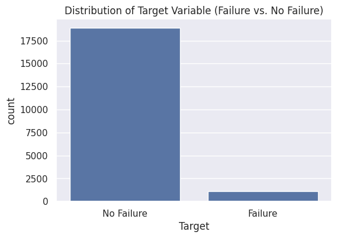

```python
# Check the distribution of the target variable
plt.figure(figsize=(6, 4))
sns.countplot(data=df, x='Target')
plt.title('Distribution of Target Variable (Failure vs. No Failure)')
plt.xticks([0, 1], ['No Failure', 'Failure'])
plt.show()
```

**Observations on the Target Variable Distribution:**

- The count plot clearly shows a significant imbalance in the target variable.
- The majority of observations belong to class 0 ("No Failure"), while a much smaller number of observations belong to class 1 ("Failure"). This confirms the earlier observation from the statistical summary and the problem statement about the rarity of generator failures.
- This class imbalance will need to be considered during model building and evaluation, as models trained on such imbalanced data may be biased towards the majority class.

[figure not shown]

[figure not shown]

[figure not shown]

[figure not shown]

[figure not shown]

[figure not shown]

[figure not shown]

[figure not shown]

[figure not shown]

[figure not shown]

[figure not shown]

[figure not shown]

[28 more figures not shown]

```python
# Univariate analysis for numerical features using histograms and boxplots

# Select only numerical columns (excluding the target)
numerical_cols = df.select_dtypes(include=np.number).columns.tolist()
numerical_cols.remove('Target')

# Plot histograms and boxplots for each numerical feature
for col in numerical_cols:
    plt.figure(figsize=(12, 4))

    # Histogram
    plt.subplot(1, 2, 1)
    sns.histplot(data=df, x=col, kde=True)
    plt.title(f'Distribution of {col}')

    # Boxplot
    plt.subplot(1, 2, 2)
    sns.boxplot(data=df, x=col)
    plt.title(f'Boxplot of {col}')

    plt.tight_layout()
    plt.show()
```

**Observations on the Distribution of Numerical Features:**

- The histograms show the distribution shapes for each numerical variable. Many of the variables appear to have distributions that are somewhat symmetrical, while others show some skewness.
- The boxplots provide a visual summary of the central tendency, spread, and potential outliers for each numerical variable.
- As observed in the statistical summary, several variables show potential outliers, indicated by points beyond the whiskers in the boxplots. These outliers are expected given the nature of sensor data and the ciphered transformation.
- The distributions and ranges vary significantly across the different variables, which is expected with diverse sensor readings and transformed data.
- Since the data is ciphered, specific interpretations of the variable distributions in terms of real-world physical units are not possible. However, these plots are useful for understanding the spread, central tendency, and presence of potential anomalies within each feature's values.

### Bivariate and multivariate Analysis

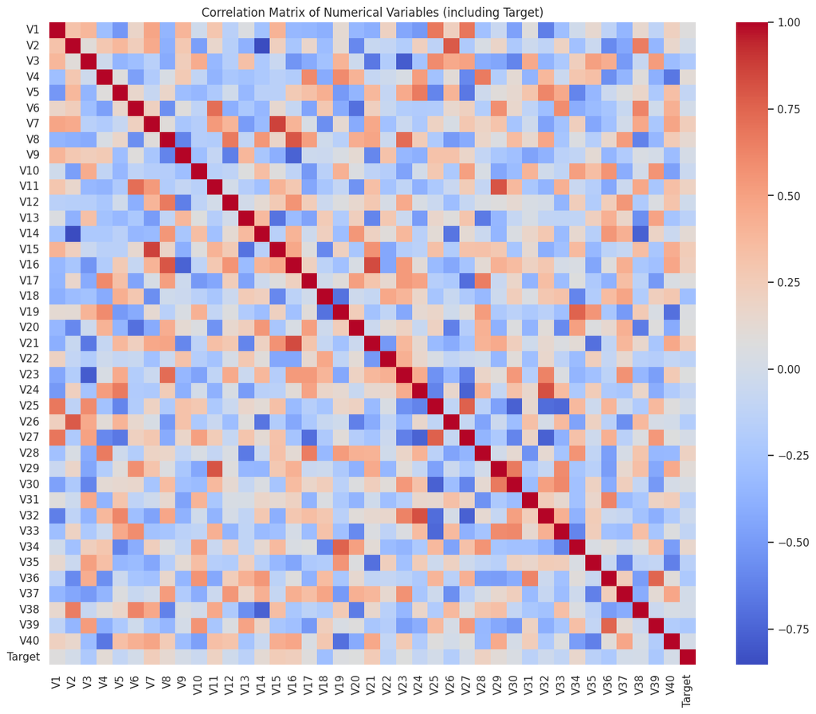

```python
# Bivariate analysis using a correlation heatmap

# Select only numerical columns (including the target for correlation)
numerical_cols_with_target = df.select_dtypes(include=np.number).columns.tolist()

# Calculate the correlation matrix
correlation_matrix = df[numerical_cols_with_target].corr()

# Plot the correlation heatmap
plt.figure(figsize=(15, 12))
sns.heatmap(correlation_matrix, cmap='coolwarm', fmt=".2f")
plt.title('Correlation Matrix of Numerical Variables (including Target)')
plt.show()
```

**Observations from the Correlation Heatmap:**

- The heatmap shows the pairwise linear correlation coefficients between all the numerical variables, including the target variable.
- The diagonal elements are all 1, representing the correlation of a variable with itself.
- The colors indicate the strength and direction of the correlation: red/orange colors represent positive correlations, while blue colors represent negative correlations. The intensity of the color indicates the strength of the correlation.
- Since the features are ciphered, we cannot interpret the correlations in terms of real-world meaning. However, we can observe which variables have strong positive or negative correlations with each other and with the target variable.
- Look at the last row (or column) corresponding to the 'Target' variable to see which features have the strongest linear relationships with the failure status. A higher absolute value of the correlation coefficient indicates a stronger linear relationship.

## Data Preprocessing

### Missing Value Treatment in Test dataset

```python
# checking for missing values
T_df.isnull().sum()
```

|  | 0 |
| --- | --- |
| V1 | 5 |
| V2 | 6 |
| V3 | 0 |
| V4 | 0 |
| V5 | 0 |
| V6 | 0 |
| V7 | 0 |
| V8 | 0 |
| V9 | 0 |
| V10 | 0 |
| V11 | 0 |
| V12 | 0 |
| V13 | 0 |
| V14 | 0 |
| V15 | 0 |
| V16 | 0 |
| V17 | 0 |
| V18 | 0 |
| V19 | 0 |
| V20 | 0 |
| V21 | 0 |
| V22 | 0 |
| V23 | 0 |
| V24 | 0 |
| V25 | 0 |
| V26 | 0 |
| V27 | 0 |
| V28 | 0 |
| V29 | 0 |
| V30 | 0 |
| V31 | 0 |
| V32 | 0 |
| V33 | 0 |
| V34 | 0 |
| V35 | 0 |
| V36 | 0 |
| V37 | 0 |
| V38 | 0 |
| V39 | 0 |
| V40 | 0 |
| Target | 0 |

**dtype:** int64

```python
# Fill missing values in V1 and V2 of the test dataset with the mean
T_df['V1'].fillna(T_df['V1'].mean(), inplace=True)
T_df['V2'].fillna(T_df['V2'].mean(), inplace=True)

# Verify that missing values have been treated
print("Missing values after treatment in test data:")
print(T_df.isnull().sum())
```

```
Missing values after treatment in test data:
V1        0
V2        0
V3        0
V4        0
V5        0
V6        0
V7        0
V8        0
V9        0
V10       0
V11       0
V12       0
V13       0
V14       0
V15       0
V16       0
V17       0
V18       0
V19       0
V20       0
V21       0
V22       0
V23       0
V24       0
V25       0
V26       0
V27       0
V28       0
V29       0
V30       0
V31       0
V32       0
V33       0
V34       0
V35       0
V36       0
V37       0
V38       0
V39       0
V40       0
Target    0
dtype: int64
```

### Normalizing the numerical variables in Train dataset

```python
# Initialize the StandardScaler
scaler = StandardScaler()

# Select numerical columns for scaling (excluding the target)
numerical_cols = df.select_dtypes(include=np.number).columns.tolist()
numerical_cols.remove('Target')

# Fit the scaler on the training data and transform the numerical columns
df[numerical_cols] = scaler.fit_transform(df[numerical_cols])

# Display the first few rows of the scaled data to verify
display(df.head())
```

|  | V1 | V2 | V3 | V4 | V5 | V6 | V7 | V8 | V9 | V10 | V11 | V12 | V13 | V14 | V15 | V16 | V17 | V18 | V19 | V20 | V21 | V22 | V23 | V24 | V25 | V26 | V27 | V28 | V29 | … |
| --- | --- | --- | --- | --- | --- | --- | --- | --- | --- | --- | --- | --- | --- | --- | --- | --- | --- | --- | --- | --- | --- | --- | --- | --- | --- | --- | --- | --- | --- | --- |
| 0 | -1.218237 | -1.624893 | 0.182021 | 0.171727 | -0.079502 | -0.508138 | -1.153250 | 0.181726 | -0.696845 | 1.721221 | -1.222480 | -0.296525 | -0.208460 | 1.323484 | -0.286395 | -0.028917 | 0.131661 | 0.665359 | 0.320348 | 1.191281 | 0.342794 | -0.184951 | -0.204474 | 0.510893 | 0.330970 | -1.276438 | 0.131770 | 0.839268 | -1.116330 | … |
| 1 | 1.057059 | 1.019756 | -0.464764 | -0.374289 | 0.183285 | 1.643564 | 0.915044 | -1.148154 | 0.269613 | -0.040162 | 1.219449 | -0.872338 | -0.986488 | -0.981160 | 0.777437 | -0.436837 | -0.619080 | -0.108645 | -0.125091 | -1.596258 | 0.153080 | 0.390439 | -0.345059 | 0.161569 | -0.131360 | 0.509818 | 0.483608 | 0.155139 | 0.658891 | … |
| 2 | -1.034376 | -1.988404 | -0.546101 | -0.680652 | -0.817236 | 0.985961 | -0.692341 | -0.796501 | -0.955815 | 2.464778 | 0.359998 | -0.169980 | -0.151752 | 1.058296 | -0.223200 | -0.313293 | -1.167177 | 0.964114 | 0.626873 | 0.282171 | 0.411544 | 0.422817 | -0.321070 | 0.139449 | -0.222442 | -1.870272 | 0.995984 | 1.052124 | -0.390384 | … |
| 3 | 0.549201 | 0.459552 | 1.346004 | -0.310106 | 0.065011 | -0.261812 | 0.616851 | -0.590299 | 0.167430 | 0.971926 | -0.370531 | -0.390770 | 0.391027 | 0.175763 | 0.584602 | -0.058940 | -0.977494 | -0.953195 | 0.117844 | -0.538342 | 0.026543 | -1.306593 | -1.305072 | -0.754618 | 1.054366 | 0.995868 | 1.227025 | -0.743257 | -1.109174 | … |
| 4 | 0.046652 | 1.089298 | -1.842220 | -0.845035 | 1.827519 | 0.754759 | 0.615786 | 1.637659 | -0.850776 | -2.830192 | 1.246298 | 1.064343 | -0.303130 | -0.580463 | -0.064888 | 1.684113 | 0.711315 | 0.981828 | -2.206337 | -1.472597 | 0.763702 | 0.672028 | 2.433603 | 0.857774 | -1.955164 | 0.788425 | -1.869650 | -1.303538 | 2.269544 | … |

### Normalizing the numerical variables in Test dataset

```python
# Select numerical columns for scaling (excluding the target)
numerical_cols = T_df.select_dtypes(include=np.number).columns.tolist()
numerical_cols.remove('Target')

# Transform the numerical columns in the test data using the scaler fitted on the training data
T_df[numerical_cols] = scaler.transform(T_df[numerical_cols])

# Display the first few rows of the scaled test data to verify
display(T_df.head())
```

|  | V1 | V2 | V3 | V4 | V5 | V6 | V7 | V8 | V9 | V10 | V11 | V12 | V13 | V14 | V15 | V16 | V17 | V18 | V19 | V20 | V21 | V22 | V23 | V24 | V25 | V26 | V27 | V28 | V29 | … |
| --- | --- | --- | --- | --- | --- | --- | --- | --- | --- | --- | --- | --- | --- | --- | --- | --- | --- | --- | --- | --- | --- | --- | --- | --- | --- | --- | --- | --- | --- | --- |
| 0 | -0.099227 | -1.352100 | -0.083331 | 0.403196 | -0.537441 | -1.715169 | -0.542974 | 1.599426 | 0.566045 | -0.149972 | -1.033044 | -0.200590 | 1.126445 | 2.357855 | -0.169703 | 1.021552 | 0.647539 | -0.656171 | -0.649096 | 1.993556 | 0.383733 | -0.482194 | 0.600210 | -0.998643 | 0.919108 | -1.066209 | 0.076711 | -0.193947 | -1.060710 | … |
| 1 | 0.192241 | -0.302399 | -0.577668 | -0.726684 | -0.457544 | 1.582893 | 0.248654 | -1.170489 | -0.146290 | 0.902718 | 1.181706 | -0.407570 | -0.327754 | -0.245287 | 0.158450 | -0.495711 | -1.103904 | 0.474002 | 0.170887 | -0.890041 | 0.117247 | 0.548360 | -0.332817 | -0.128054 | -0.290432 | -0.521128 | 0.830068 | 0.365501 | 0.450599 | … |
| 2 | -0.175173 | -0.343117 | 0.471986 | -0.439254 | 0.275381 | -0.471429 | 0.104427 | 0.575149 | -0.794043 | 0.218635 | -0.970738 | 0.668939 | -0.706124 | 0.164498 | 0.670203 | 0.306759 | 0.725217 | 0.465682 | -0.170903 | 0.482350 | 0.417932 | -0.284508 | -0.117713 | 0.167641 | 0.930526 | -0.439544 | 0.101482 | 0.208267 | -0.422217 | … |
| 3 | 0.148300 | 0.323158 | 0.451426 | 0.762822 | 0.594246 | -1.039672 | -0.025381 | 0.248110 | 0.619873 | 0.326172 | -1.178830 | -0.837941 | 0.351368 | 0.960015 | 0.007209 | 0.138161 | 0.211078 | -0.819030 | -0.198164 | 0.323517 | 0.098589 | -0.513016 | -0.072613 | 0.092976 | 0.546683 | 0.660602 | 0.083312 | -0.132087 | -1.628055 | … |
| 4 | 1.772527 | 0.738828 | -1.097481 | 0.842899 | -0.754435 | -0.201505 | 0.821970 | 0.459159 | 0.895706 | -1.259313 | 0.437026 | -0.078584 | -0.776260 | -0.407259 | 0.606808 | -0.359559 | 1.204084 | -0.693226 | 0.519048 | 0.093647 | -0.610447 | 2.207497 | 1.194610 | 0.534399 | 0.197793 | -0.473361 | -0.400490 | 1.023430 | 0.190944 | … |

### Splitting the dataset

```python
## Separating Independent and Dependent Columns
X = df.drop(['Target'],axis=1)
Y = df['Target']
```

```python
## Separating Independent and Dependent Columns
X_test = T_df.drop(['Target'],axis=1)
Y_test = T_df['Target']
```

```python
# Splitting the dataset into the Training and Test set.
X_train, X_valid, y_train, y_valid = train_test_split(X,Y, test_size = 0.2, random_state = 42,stratify = Y)
```

```python
#Printing the shapes.
print(X_train.shape,y_train.shape)
print(X_valid.shape,y_valid.shape)
print(X_test.shape,y_valid.shape)
```

```
(16000, 40) (16000,)
(4000, 40) (4000,)
(5000, 40) (4000,)
```

```python
# y_train = y_train.to_numpy()
# y_valid = y_valid.to_numpy()
```

```python
Y_Test = Y_test.to_numpy()
```

### Missing Value Treatment in Train dataset

```python
# checking for missing values
X_train.isnull().sum()
```

|  | 0 |
| --- | --- |
| V1 | 15 |
| V2 | 15 |
| V3 | 0 |
| V4 | 0 |
| V5 | 0 |
| V6 | 0 |
| V7 | 0 |
| V8 | 0 |
| V9 | 0 |
| V10 | 0 |
| V11 | 0 |
| V12 | 0 |
| V13 | 0 |
| V14 | 0 |
| V15 | 0 |
| V16 | 0 |
| V17 | 0 |
| V18 | 0 |
| V19 | 0 |
| V20 | 0 |
| V21 | 0 |
| V22 | 0 |
| V23 | 0 |
| V24 | 0 |
| V25 | 0 |
| V26 | 0 |
| V27 | 0 |
| V28 | 0 |
| V29 | 0 |
| V30 | 0 |
| V31 | 0 |
| V32 | 0 |
| V33 | 0 |
| V34 | 0 |
| V35 | 0 |
| V36 | 0 |
| V37 | 0 |
| V38 | 0 |
| V39 | 0 |
| V40 | 0 |

**dtype:** int64

```python
# Fill missing values in V1 and V2 with the mean
X_train['V1'].fillna(X_train['V1'].mean(), inplace=True)
X_train['V2'].fillna(X_train['V2'].mean(), inplace=True)

# Verify that missing values have been treated
print("Missing values after treatment in training data:")
print(X_train.isnull().sum())
```

```
Missing values after treatment in training data:
V1     0
V2     0
V3     0
V4     0
V5     0
V6     0
V7     0
V8     0
V9     0
V10    0
V11    0
V12    0
V13    0
V14    0
V15    0
V16    0
V17    0
V18    0
V19    0
V20    0
V21    0
V22    0
V23    0
V24    0
V25    0
V26    0
V27    0
V28    0
V29    0
V30    0
V31    0
V32    0
V33    0
V34    0
V35    0
V36    0
V37    0
V38    0
V39    0
V40    0
dtype: int64
```

```python
# checking for missing values
X_valid.isnull().sum()
```

|  | 0 |
| --- | --- |
| V1 | 3 |
| V2 | 3 |
| V3 | 0 |
| V4 | 0 |
| V5 | 0 |
| V6 | 0 |
| V7 | 0 |
| V8 | 0 |
| V9 | 0 |
| V10 | 0 |
| V11 | 0 |
| V12 | 0 |
| V13 | 0 |
| V14 | 0 |
| V15 | 0 |
| V16 | 0 |
| V17 | 0 |
| V18 | 0 |
| V19 | 0 |
| V20 | 0 |
| V21 | 0 |
| V22 | 0 |
| V23 | 0 |
| V24 | 0 |
| V25 | 0 |
| V26 | 0 |
| V27 | 0 |
| V28 | 0 |
| V29 | 0 |
| V30 | 0 |
| V31 | 0 |
| V32 | 0 |
| V33 | 0 |
| V34 | 0 |
| V35 | 0 |
| V36 | 0 |
| V37 | 0 |
| V38 | 0 |
| V39 | 0 |
| V40 | 0 |

**dtype:** int64

```python
# Fill missing values in V1 and V2 with the mean
X_valid['V1'].fillna(X_valid['V1'].mean(), inplace=True)
X_valid['V2'].fillna(X_valid['V2'].mean(), inplace=True)

# Verify that missing values have been treated
print("Missing values after treatment in training data:")
print(X_valid.isnull().sum())
```

```
Missing values after treatment in training data:
V1     0
V2     0
V3     0
V4     0
V5     0
V6     0
V7     0
V8     0
V9     0
V10    0
V11    0
V12    0
V13    0
V14    0
V15    0
V16    0
V17    0
V18    0
V19    0
V20    0
V21    0
V22    0
V23    0
V24    0
V25    0
V26    0
V27    0
V28    0
V29    0
V30    0
V31    0
V32    0
V33    0
V34    0
V35    0
V36    0
V37    0
V38    0
V39    0
V40    0
dtype: int64
```

### Utility functions

```python
def plot(history, name):
    """
    Function to plot loss/accuracy

    history: an object which stores the metrics and losses.
    name: can be one of Loss or Accuracy
    """
    fig, ax = plt.subplots() #Creating a subplot with figure and axes.
    plt.plot(history.history[name]) #Plotting the train accuracy or train loss
    plt.plot(history.history['val_'+name]) #Plotting the validation accuracy or validation loss

    plt.title('Model ' + name.capitalize()) #Defining the title of the plot.
    plt.ylabel(name.capitalize()) #Defining the label for the x-axis.
    plt.xlabel('Epoch') #Defining the label for the x-axis.
    fig.legend(['Train', 'Validation'], loc="outside right upper") #Defining the legend, loc controls the position of the legend.
```

```python
# defining a function to compute different metrics to check performance of a classification model built using statsmodels
def model_performance_classification(
    model, predictors, target, threshold=0.5
):
    """
    Function to compute different metrics to check classification model performance

    model: classifier
    predictors: independent variables
    target: dependent variable
    threshold: threshold for classifying the observation as class 1
    """

    # checking which probabilities are greater than threshold
    pred = model.predict(predictors) > threshold
    # pred_temp = model.predict(predictors) > threshold
    # # rounding off the above values to get classes
    # pred = np.round(pred_temp)

    acc = accuracy_score(target, pred)  # to compute Accuracy
    recall = recall_score(target, pred, average='weighted')  # to compute Recall
    precision = precision_score(target, pred, average='weighted')  # to compute Precision
    f1 = f1_score(target, pred, average='weighted')  # to compute F1-score

    # creating a dataframe of metrics
    df_perf = pd.DataFrame(
        {"Accuracy": acc, "Recall": recall, "Precision": precision, "F1 Score": f1,},
        index=[0],
    )

    return df_perf
```

We'll create a dataframe to store the results from all the models we build

```python
#Defining the columns of the dataframe which are nothing but the hyper parameters and the metrics.
columns = ["# hidden layers","# neurons - hidden layer","activation function - hidden layer ","# epochs","batch size","optimizer","learning rate, momentum","weight initializer","regularization","train loss","validation loss","train accuracy","validation accuracy","time (secs)"]

#Creating a pandas dataframe.
results = pd.DataFrame(columns=columns)
```

## Model Building

### Model Evaluation Criterion

**Model can make wrong predictions as:**

1. Predicting 'No Failure' when there is a 'Failure': This is a False Negative (FN). The model fails to detect an actual failure. As mentioned in the problem statement, this leads to a high replacement cost. Minimizing these is crucial.
2. Predicting 'Failure' when there is 'No Failure': This is a False Positive (FP). The model incorrectly predicts a failure when there isn't one. This leads to an inspection cost.

**Which case is more important?**

Based on the problem statement:

1. False Negatives (Predicting 'No Failure' when there is a 'Failure') result in high replacement costs.
2. False Positives (Predicting 'Failure' when there is 'No Failure') result in lower inspection costs.

Since the cost of replacement is much higher than the cost of inspection, minimizing False Negatives is the more critical objective for this problem. This means we want our model to be good at identifying actual failures, even if it means predicting a failure occasionally when there isn't one (False Positive). **How to reduce this loss i.e need to reduce False Negatives?**

- `Minimizing False Negatives is the most crucial goal. To minimize False Negatives, we need to maximize Recall for the 'Failure' class (Target = 1). While Recall is the main focus, we should also consider Precision (to keep False Positives and associated inspection costs in check) and the F1-score (which balances Recall and Precision) as secondary metrics to get a more complete picture of the model's performance.

In summary, the primary evaluation metric for this problem is Recall.

As we have are dealing with an imbalance in class distribution, we will be using class weights to allow the model to give proportionally more importance to the minority class.

```python
# Calculate class weights for imbalanced dataset
cw = (y_train.shape[0]) / np.bincount(y_train)

# Create a dictionary mapping class indices to their respective class weights
cw_dict = {}
for i in range(cw.shape[0]):
    cw_dict[i] = cw[i]

cw_dict
```

```
{0: np.float64(1.0587612493382743), 1: np.float64(18.01801801801802)}
```

```python
# defining the batch size and # epochs upfront as we'll be using the same values for all models
epochs = 25
batch_size = 64
```

### Model 0

- Let's start with a neural network consisting of
  - two hidden layers with 14 and 7 neurons respectively
  - activation function of ReLU.
  - SGD as the optimizer

```python
# clears the current Keras session, resetting all layers and models previously created, freeing up memory and resources.
tf.keras.backend.clear_session()
```

```python
#Initializing the neural network
model = Sequential()
model.add(Dense(14,activation="relu",input_dim=X_train.shape[1]))
model.add(Dense(7,activation="relu"))
model.add(Dense(1,activation="sigmoid"))
```

```python
model.summary()
```

```
Model: "sequential"
```

```
┏━━━━━━━━━━━━━━━━━━━━━━━━━━━━━━━━━┳━━━━━━━━━━━━━━━━━━━━━━━━┳━━━━━━━━━━━━━━━┓
┃ Layer (type)                    ┃ Output Shape           ┃       Param # ┃
┡━━━━━━━━━━━━━━━━━━━━━━━━━━━━━━━━━╇━━━━━━━━━━━━━━━━━━━━━━━━╇━━━━━━━━━━━━━━━┩
│ dense (Dense)                   │ (None, 14)             │           574 │
├─────────────────────────────────┼────────────────────────┼───────────────┤
│ dense_1 (Dense)                 │ (None, 7)              │           105 │
├─────────────────────────────────┼────────────────────────┼───────────────┤
│ dense_2 (Dense)                 │ (None, 1)              │             8 │
└─────────────────────────────────┴────────────────────────┴───────────────┘
```

```
 Total params: 687 (2.68 KB)
```

```
 Trainable params: 687 (2.68 KB)
```

```
 Non-trainable params: 0 (0.00 B)
```

```python
optimizer = tf.keras.optimizers.SGD()    # defining SGD as the optimizer to be used
model.compile(loss='binary_crossentropy', optimizer=optimizer, metrics=['accuracy'])
```

```python
start = time.time()
history = model.fit(X_train, y_train, validation_data=(X_valid,y_valid) , batch_size=batch_size, epochs=epochs,class_weight=cw_dict)
end=time.time()
```

```
250/250 ━━━━━━━━━━━━━━━━━━━━ 4s 8ms/step - accuracy: 0.3048 - loss: 1.2492 - val_accuracy: 0.8270 - val_loss: 0.5207
250/250 ━━━━━━━━━━━━━━━━━━━━ 3s 11ms/step - accuracy: 0.8711 - loss: 0.7363 - val_accuracy: 0.8985 - val_loss: 0.3342
250/250 ━━━━━━━━━━━━━━━━━━━━ 3s 3ms/step - accuracy: 0.9138 - loss: 0.5891 - val_accuracy: 0.9200 - val_loss: 0.2641
250/250 ━━━━━━━━━━━━━━━━━━━━ 1s 3ms/step - accuracy: 0.9301 - loss: 0.5270 - val_accuracy: 0.9317 - val_loss: 0.2334
250/250 ━━━━━━━━━━━━━━━━━━━━ 1s 3ms/step - accuracy: 0.9419 - loss: 0.4899 - val_accuracy: 0.9365 - val_loss: 0.2157
250/250 ━━━━━━━━━━━━━━━━━━━━ 1s 3ms/step - accuracy: 0.9507 - loss: 0.4662 - val_accuracy: 0.9438 - val_loss: 0.2018
250/250 ━━━━━━━━━━━━━━━━━━━━ 1s 3ms/step - accuracy: 0.9562 - loss: 0.4496 - val_accuracy: 0.9473 - val_loss: 0.1922
250/250 ━━━━━━━━━━━━━━━━━━━━ 1s 3ms/step - accuracy: 0.9601 - loss: 0.4352 - val_accuracy: 0.9563 - val_loss: 0.1804
250/250 ━━━━━━━━━━━━━━━━━━━━ 1s 3ms/step - accuracy: 0.9632 - loss: 0.4221 - val_accuracy: 0.9585 - val_loss: 0.1784
250/250 ━━━━━━━━━━━━━━━━━━━━ 1s 3ms/step - accuracy: 0.9658 - loss: 0.4139 - val_accuracy: 0.9610 - val_loss: 0.1754
250/250 ━━━━━━━━━━━━━━━━━━━━ 1s 4ms/step - accuracy: 0.9671 - loss: 0.4061 - val_accuracy: 0.9640 - val_loss: 0.1720
250/250 ━━━━━━━━━━━━━━━━━━━━ 1s 4ms/step - accuracy: 0.9685 - loss: 0.3995 - val_accuracy: 0.9657 - val_loss: 0.1677
250/250 ━━━━━━━━━━━━━━━━━━━━ 1s 5ms/step - accuracy: 0.9693 - loss: 0.3933 - val_accuracy: 0.9657 - val_loss: 0.1666
250/250 ━━━━━━━━━━━━━━━━━━━━ 2s 3ms/step - accuracy: 0.9696 - loss: 0.3880 - val_accuracy: 0.9655 - val_loss: 0.1661
250/250 ━━━━━━━━━━━━━━━━━━━━ 1s 3ms/step - accuracy: 0.9703 - loss: 0.3824 - val_accuracy: 0.9650 - val_loss: 0.1653
250/250 ━━━━━━━━━━━━━━━━━━━━ 1s 3ms/step - accuracy: 0.9713 - loss: 0.3770 - val_accuracy: 0.9653 - val_loss: 0.1646
250/250 ━━━━━━━━━━━━━━━━━━━━ 1s 3ms/step - accuracy: 0.9717 - loss: 0.3729 - val_accuracy: 0.9655 - val_loss: 0.1636
250/250 ━━━━━━━━━━━━━━━━━━━━ 1s 3ms/step - accuracy: 0.9726 - loss: 0.3689 - val_accuracy: 0.9650 - val_loss: 0.1625
250/250 ━━━━━━━━━━━━━━━━━━━━ 1s 4ms/step - accuracy: 0.9725 - loss: 0.3651 - val_accuracy: 0.9653 - val_loss: 0.1635
250/250 ━━━━━━━━━━━━━━━━━━━━ 2s 8ms/step - accuracy: 0.9730 - loss: 0.3616 - val_accuracy: 0.9670 - val_loss: 0.1587
250/250 ━━━━━━━━━━━━━━━━━━━━ 1s 3ms/step - accuracy: 0.9739 - loss: 0.3571 - val_accuracy: 0.9665 - val_loss: 0.1579
250/250 ━━━━━━━━━━━━━━━━━━━━ 1s 3ms/step - accuracy: 0.9745 - loss: 0.3541 - val_accuracy: 0.9675 - val_loss: 0.1573
250/250 ━━━━━━━━━━━━━━━━━━━━ 2s 5ms/step - accuracy: 0.9753 - loss: 0.3505 - val_accuracy: 0.9688 - val_loss: 0.1556
250/250 ━━━━━━━━━━━━━━━━━━━━ 1s 5ms/step - accuracy: 0.9752 - loss: 0.3473 - val_accuracy: 0.9682 - val_loss: 0.1544
250/250 ━━━━━━━━━━━━━━━━━━━━ 1s 4ms/step - accuracy: 0.9753 - loss: 0.3447 - val_accuracy: 0.9690 - val_loss: 0.1524
```

```python
print("Time taken in seconds ",end-start)
```

```
Time taken in seconds  36.57655334472656
```

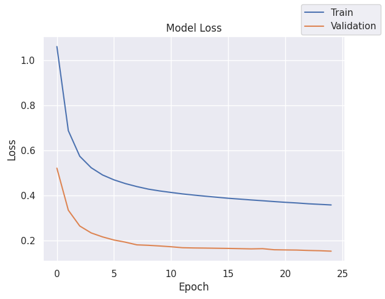

```python
plot(history,'loss')
```

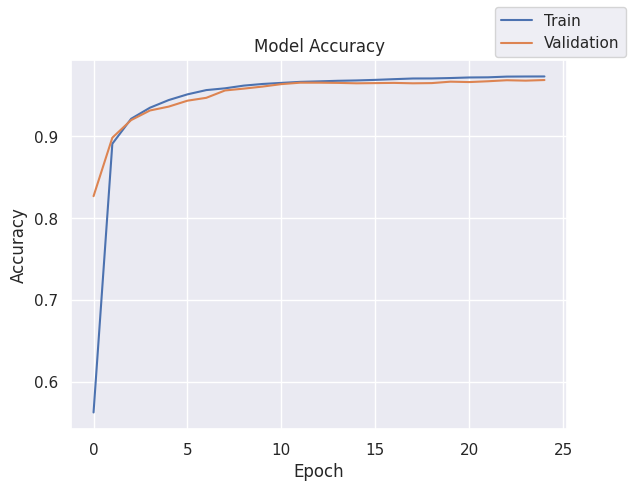

```python
plot(history,'accuracy')
```

```python
model_0_train_perf = model_performance_classification(model, X_train, y_train)
model_0_train_perf
```

```
500/500 ━━━━━━━━━━━━━━━━━━━━ 1s 1ms/step
```

|  | Accuracy | Recall | Precision | F1 Score |
| --- | --- | --- | --- | --- |
| 0 | 0.969187 | 0.969187 | 0.976358 | 0.971504 |

```python
model_0_valid_perf = model_performance_classification(model, X_valid, y_valid)
model_0_valid_perf
```

```
125/125 ━━━━━━━━━━━━━━━━━━━━ 0s 1ms/step
```

|  | Accuracy | Recall | Precision | F1 Score |
| --- | --- | --- | --- | --- |
| 0 | 0.969 | 0.969 | 0.976219 | 0.971337 |

- It shows consistent performance of the model between training and testing datasets.
- Even though it's a good score, the rate of improvement over the epochs is still low.

```python
results.loc[0] = [2,str([14,7]),str(["relu","relu"]),25,64,"sgd",str([0.001, "-"]),"xavier","-",history.history["loss"][-1],history.history["val_loss"][-1],history.history["accuracy"][-1],history.history["val_accuracy"][-1],round(end-start,2)]
```

```python
results
```

|  | # hidden layers | # neurons - hidden layer | activation function - hidden layer | # epochs | batch size | optimizer | learning rate, momentum | weight initializer | regularization | train loss | validation loss | train accuracy | validation accuracy | time (secs) |
| --- | --- | --- | --- | --- | --- | --- | --- | --- | --- | --- | --- | --- | --- | --- |
| 0 | 2 | [14, 7] | ['relu', 'relu'] | 25 | 64 | sgd | [0.001, '-'] | xavier | - | 0.357475 | 0.152401 | 0.973375 | 0.969 | 36.58 |

**Let's try using the SGD optimizer with momentum.**

### Model 1

- After the 9th epoch, the model's rate of learning is low.
- Let's try adding momentum to check whether it's accelerating the learning process.

```python
# clears the current Keras session, resetting all layers and models previously created, freeing up memory and resources.
tf.keras.backend.clear_session()
```

```python
#Initializing the neural network
model = Sequential()
model.add(Dense(14,activation="relu",input_dim=X_train.shape[1]))
model.add(Dense(7,activation="relu"))
model.add(Dense(1,activation="sigmoid"))
```

```python
model.summary()
```

```
Model: "sequential"
```

```
┏━━━━━━━━━━━━━━━━━━━━━━━━━━━━━━━━━┳━━━━━━━━━━━━━━━━━━━━━━━━┳━━━━━━━━━━━━━━━┓
┃ Layer (type)                    ┃ Output Shape           ┃       Param # ┃
┡━━━━━━━━━━━━━━━━━━━━━━━━━━━━━━━━━╇━━━━━━━━━━━━━━━━━━━━━━━━╇━━━━━━━━━━━━━━━┩
│ dense (Dense)                   │ (None, 14)             │           574 │
├─────────────────────────────────┼────────────────────────┼───────────────┤
│ dense_1 (Dense)                 │ (None, 7)              │           105 │
├─────────────────────────────────┼────────────────────────┼───────────────┤
│ dense_2 (Dense)                 │ (None, 1)              │             8 │
└─────────────────────────────────┴────────────────────────┴───────────────┘
```

```
 Total params: 687 (2.68 KB)
```

```
 Trainable params: 687 (2.68 KB)
```

```
 Non-trainable params: 0 (0.00 B)
```

```python
optimizer = tf.keras.optimizers.SGD(momentum=0.9)    # defining SGD as the optimizer to be used
model.compile(loss='binary_crossentropy', optimizer=optimizer, metrics=['accuracy'])
```

```python
start = time.time()
history = model.fit(X_train, y_train, validation_data=(X_valid,y_valid) , batch_size=batch_size, epochs=epochs,class_weight = cw_dict)
end=time.time()
```

```
250/250 ━━━━━━━━━━━━━━━━━━━━ 2s 4ms/step - accuracy: 0.7514 - loss: 0.8597 - val_accuracy: 0.9250 - val_loss: 0.2449
250/250 ━━━━━━━━━━━━━━━━━━━━ 1s 3ms/step - accuracy: 0.9480 - loss: 0.4741 - val_accuracy: 0.9408 - val_loss: 0.2101
250/250 ━━━━━━━━━━━━━━━━━━━━ 1s 3ms/step - accuracy: 0.9612 - loss: 0.4279 - val_accuracy: 0.9255 - val_loss: 0.2312
250/250 ━━━━━━━━━━━━━━━━━━━━ 1s 3ms/step - accuracy: 0.9625 - loss: 0.4074 - val_accuracy: 0.9255 - val_loss: 0.2496
250/250 ━━━━━━━━━━━━━━━━━━━━ 1s 3ms/step - accuracy: 0.9669 - loss: 0.3875 - val_accuracy: 0.9293 - val_loss: 0.2325
250/250 ━━━━━━━━━━━━━━━━━━━━ 1s 3ms/step - accuracy: 0.9707 - loss: 0.3669 - val_accuracy: 0.9438 - val_loss: 0.1940
250/250 ━━━━━━━━━━━━━━━━━━━━ 1s 3ms/step - accuracy: 0.9679 - loss: 0.3773 - val_accuracy: 0.9277 - val_loss: 0.2448
250/250 ━━━━━━━━━━━━━━━━━━━━ 1s 3ms/step - accuracy: 0.9686 - loss: 0.3519 - val_accuracy: 0.9227 - val_loss: 0.2674
250/250 ━━━━━━━━━━━━━━━━━━━━ 1s 4ms/step - accuracy: 0.9700 - loss: 0.3410 - val_accuracy: 0.9290 - val_loss: 0.2536
250/250 ━━━━━━━━━━━━━━━━━━━━ 1s 5ms/step - accuracy: 0.9735 - loss: 0.3379 - val_accuracy: 0.9240 - val_loss: 0.2759
250/250 ━━━━━━━━━━━━━━━━━━━━ 2s 4ms/step - accuracy: 0.9737 - loss: 0.3286 - val_accuracy: 0.9405 - val_loss: 0.2427
250/250 ━━━━━━━━━━━━━━━━━━━━ 1s 3ms/step - accuracy: 0.9742 - loss: 0.3257 - val_accuracy: 0.9550 - val_loss: 0.2011
250/250 ━━━━━━━━━━━━━━━━━━━━ 1s 3ms/step - accuracy: 0.9756 - loss: 0.3222 - val_accuracy: 0.9390 - val_loss: 0.2460
250/250 ━━━━━━━━━━━━━━━━━━━━ 1s 3ms/step - accuracy: 0.9748 - loss: 0.3210 - val_accuracy: 0.9582 - val_loss: 0.1856
250/250 ━━━━━━━━━━━━━━━━━━━━ 1s 4ms/step - accuracy: 0.9768 - loss: 0.3082 - val_accuracy: 0.9423 - val_loss: 0.2339
250/250 ━━━━━━━━━━━━━━━━━━━━ 1s 4ms/step - accuracy: 0.9766 - loss: 0.3156 - val_accuracy: 0.9588 - val_loss: 0.1830
250/250 ━━━━━━━━━━━━━━━━━━━━ 1s 3ms/step - accuracy: 0.9739 - loss: 0.3154 - val_accuracy: 0.9495 - val_loss: 0.2200
250/250 ━━━━━━━━━━━━━━━━━━━━ 1s 3ms/step - accuracy: 0.9717 - loss: 0.3367 - val_accuracy: 0.9523 - val_loss: 0.1938
250/250 ━━━━━━━━━━━━━━━━━━━━ 2s 6ms/step - accuracy: 0.9772 - loss: 0.2975 - val_accuracy: 0.9523 - val_loss: 0.2079
250/250 ━━━━━━━━━━━━━━━━━━━━ 2s 5ms/step - accuracy: 0.9747 - loss: 0.3092 - val_accuracy: 0.9605 - val_loss: 0.1753
250/250 ━━━━━━━━━━━━━━━━━━━━ 1s 4ms/step - accuracy: 0.9679 - loss: 0.3493 - val_accuracy: 0.9688 - val_loss: 0.1498
250/250 ━━━━━━━━━━━━━━━━━━━━ 1s 3ms/step - accuracy: 0.9765 - loss: 0.3083 - val_accuracy: 0.9737 - val_loss: 0.1292
250/250 ━━━━━━━━━━━━━━━━━━━━ 1s 3ms/step - accuracy: 0.9769 - loss: 0.3003 - val_accuracy: 0.9635 - val_loss: 0.1576
250/250 ━━━━━━━━━━━━━━━━━━━━ 1s 3ms/step - accuracy: 0.9765 - loss: 0.3045 - val_accuracy: 0.9695 - val_loss: 0.1390
250/250 ━━━━━━━━━━━━━━━━━━━━ 1s 3ms/step - accuracy: 0.9750 - loss: 0.3017 - val_accuracy: 0.9685 - val_loss: 0.1443
```

```python
print("Time taken in seconds ",end-start)
```

```
Time taken in seconds  32.597334146499634
```

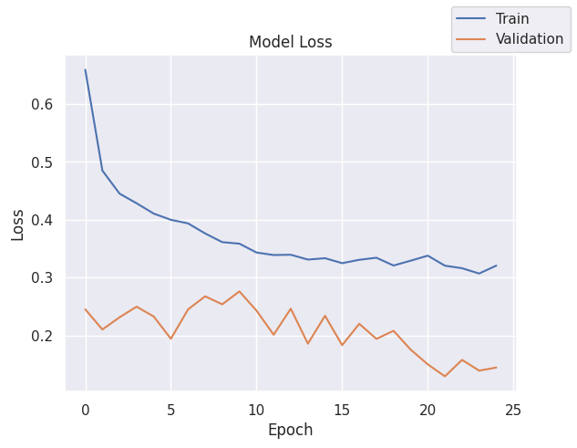

```python
plot(history,'loss')
```

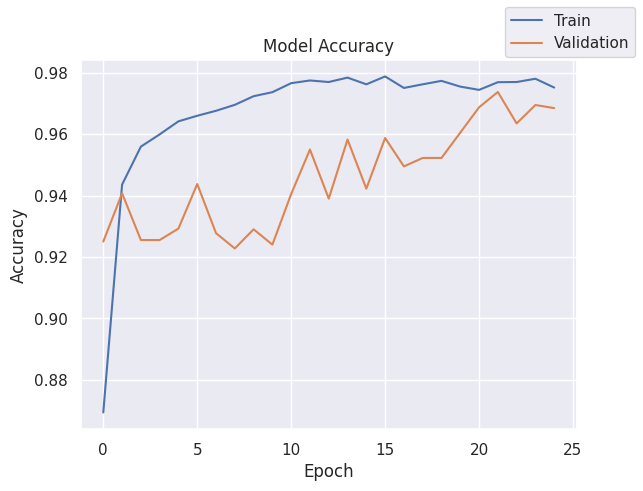

```python
plot(history,'accuracy')
```

```python
model_1_train_perf = model_performance_classification(model, X_train, y_train)
model_1_train_perf
```

```
500/500 ━━━━━━━━━━━━━━━━━━━━ 1s 1ms/step
```

|  | Accuracy | Recall | Precision | F1 Score |
| --- | --- | --- | --- | --- |
| 0 | 0.973688 | 0.973688 | 0.978922 | 0.975371 |

```python
model_1_valid_perf = model_performance_classification(model, X_valid, y_valid)
model_1_valid_perf
```

```
125/125 ━━━━━━━━━━━━━━━━━━━━ 0s 1ms/step
```

|  | Accuracy | Recall | Precision | F1 Score |
| --- | --- | --- | --- | --- |
| 0 | 0.9685 | 0.9685 | 0.975783 | 0.970874 |

```python
results.loc[1] = [2,str([14,7]),str(["relu","relu"]),25,64,"sgd with momentum",str([0.001, 0.9]),"xavier","-",history.history["loss"][-1],history.history["val_loss"][-1],history.history["accuracy"][-1],history.history["val_accuracy"][-1],round(end-start,2)]
```

```python
results
```

|  | # hidden layers | # neurons - hidden layer | activation function - hidden layer | # epochs | batch size | optimizer | learning rate, momentum | weight initializer | regularization | train loss | validation loss | train accuracy | validation accuracy | time (secs) |
| --- | --- | --- | --- | --- | --- | --- | --- | --- | --- | --- | --- | --- | --- | --- |
| 0 | 2 | [14, 7] | ['relu', 'relu'] | 25 | 64 | sgd | [0.001, '-'] | xavier | - | 0.357475 | 0.152401 | 0.973375 | 0.9690 | 36.58 |
| 1 | 2 | [14, 7] | ['relu', 'relu'] | 25 | 64 | sgd with momentum | [0.001, 0.9] | xavier | - | 0.320486 | 0.144340 | 0.975187 | 0.9685 | 32.60 |

- Compared to Model 0, Model 1 (with SGD optimizer with momentum) shows slightly higher accuracy and recall on the training data.
- However, the validation performance of Model 1 is slightly lower than Model 0 in terms of accuracy, recall, and F1 score.
- The loss and accuracy plots show that while the training loss decreases and training accuracy increases, there is some fluctuation in the validation loss and accuracy, suggesting that the addition of momentum with the current learning rate might be causing the model to overshoot the optimal point on the validation set at times.
- While Model 1's training metrics are impressive, the slightly reduced validation performance compared to Model 0 suggests that the added momentum might not be providing a consistent improvement in generalization on this specific network architecture and hyperparameters.

### Model 2

- Let's change the optimizer to Adam
  - This will introduce momentum as well as an adaptive learning rate

```python
# clears the current Keras session, resetting all layers and models previously created, freeing up memory and resources.
tf.keras.backend.clear_session()
```

```python
#Initializing the neural network
model = Sequential()
model.add(Dense(14,activation="relu",input_dim=X_train.shape[1]))
model.add(Dense(7,activation="relu"))
model.add(Dense(1,activation="sigmoid"))
```

```python
model.summary()
```

```
Model: "sequential"
```

```
┏━━━━━━━━━━━━━━━━━━━━━━━━━━━━━━━━━┳━━━━━━━━━━━━━━━━━━━━━━━━┳━━━━━━━━━━━━━━━┓
┃ Layer (type)                    ┃ Output Shape           ┃       Param # ┃
┡━━━━━━━━━━━━━━━━━━━━━━━━━━━━━━━━━╇━━━━━━━━━━━━━━━━━━━━━━━━╇━━━━━━━━━━━━━━━┩
│ dense (Dense)                   │ (None, 14)             │           574 │
├─────────────────────────────────┼────────────────────────┼───────────────┤
│ dense_1 (Dense)                 │ (None, 7)              │           105 │
├─────────────────────────────────┼────────────────────────┼───────────────┤
│ dense_2 (Dense)                 │ (None, 1)              │             8 │
└─────────────────────────────────┴────────────────────────┴───────────────┘
```

```
 Total params: 687 (2.68 KB)
```

```
 Trainable params: 687 (2.68 KB)
```

```
 Non-trainable params: 0 (0.00 B)
```

```python
optimizer = tf.keras.optimizers.Adam()    # defining Adam as the optimizer to be used
model.compile(loss='binary_crossentropy', optimizer=optimizer, metrics=['accuracy'])
```

```python
start = time.time()
history = model.fit(X_train, y_train, validation_data=(X_valid,y_valid) , batch_size=batch_size, epochs=epochs,class_weight=cw_dict)
end=time.time()
```

```
250/250 ━━━━━━━━━━━━━━━━━━━━ 2s 4ms/step - accuracy: 0.6153 - loss: 0.9883 - val_accuracy: 0.8690 - val_loss: 0.3492
250/250 ━━━━━━━━━━━━━━━━━━━━ 1s 3ms/step - accuracy: 0.8931 - loss: 0.5969 - val_accuracy: 0.9055 - val_loss: 0.2666
250/250 ━━━━━━━━━━━━━━━━━━━━ 1s 3ms/step - accuracy: 0.9228 - loss: 0.5228 - val_accuracy: 0.9290 - val_loss: 0.2270
250/250 ━━━━━━━━━━━━━━━━━━━━ 1s 3ms/step - accuracy: 0.9384 - loss: 0.4834 - val_accuracy: 0.9392 - val_loss: 0.2043
250/250 ━━━━━━━━━━━━━━━━━━━━ 1s 3ms/step - accuracy: 0.9503 - loss: 0.4546 - val_accuracy: 0.9460 - val_loss: 0.1892
250/250 ━━━━━━━━━━━━━━━━━━━━ 2s 5ms/step - accuracy: 0.9572 - loss: 0.4335 - val_accuracy: 0.9505 - val_loss: 0.1820
250/250 ━━━━━━━━━━━━━━━━━━━━ 1s 3ms/step - accuracy: 0.9620 - loss: 0.4187 - val_accuracy: 0.9555 - val_loss: 0.1743
250/250 ━━━━━━━━━━━━━━━━━━━━ 1s 3ms/step - accuracy: 0.9643 - loss: 0.4069 - val_accuracy: 0.9613 - val_loss: 0.1666
250/250 ━━━━━━━━━━━━━━━━━━━━ 1s 4ms/step - accuracy: 0.9664 - loss: 0.3970 - val_accuracy: 0.9628 - val_loss: 0.1634
250/250 ━━━━━━━━━━━━━━━━━━━━ 1s 5ms/step - accuracy: 0.9672 - loss: 0.3892 - val_accuracy: 0.9660 - val_loss: 0.1588
250/250 ━━━━━━━━━━━━━━━━━━━━ 2s 3ms/step - accuracy: 0.9687 - loss: 0.3825 - val_accuracy: 0.9655 - val_loss: 0.1561
250/250 ━━━━━━━━━━━━━━━━━━━━ 1s 3ms/step - accuracy: 0.9694 - loss: 0.3769 - val_accuracy: 0.9660 - val_loss: 0.1534
250/250 ━━━━━━━━━━━━━━━━━━━━ 1s 3ms/step - accuracy: 0.9701 - loss: 0.3700 - val_accuracy: 0.9670 - val_loss: 0.1521
250/250 ━━━━━━━━━━━━━━━━━━━━ 1s 3ms/step - accuracy: 0.9713 - loss: 0.3640 - val_accuracy: 0.9670 - val_loss: 0.1506
250/250 ━━━━━━━━━━━━━━━━━━━━ 1s 3ms/step - accuracy: 0.9715 - loss: 0.3589 - val_accuracy: 0.9668 - val_loss: 0.1494
250/250 ━━━━━━━━━━━━━━━━━━━━ 1s 3ms/step - accuracy: 0.9718 - loss: 0.3550 - val_accuracy: 0.9675 - val_loss: 0.1462
250/250 ━━━━━━━━━━━━━━━━━━━━ 1s 3ms/step - accuracy: 0.9727 - loss: 0.3510 - val_accuracy: 0.9672 - val_loss: 0.1453
250/250 ━━━━━━━━━━━━━━━━━━━━ 1s 3ms/step - accuracy: 0.9740 - loss: 0.3469 - val_accuracy: 0.9690 - val_loss: 0.1416
250/250 ━━━━━━━━━━━━━━━━━━━━ 1s 3ms/step - accuracy: 0.9747 - loss: 0.3434 - val_accuracy: 0.9688 - val_loss: 0.1415
250/250 ━━━━━━━━━━━━━━━━━━━━ 2s 5ms/step - accuracy: 0.9745 - loss: 0.3395 - val_accuracy: 0.9693 - val_loss: 0.1398
250/250 ━━━━━━━━━━━━━━━━━━━━ 2s 4ms/step - accuracy: 0.9748 - loss: 0.3356 - val_accuracy: 0.9685 - val_loss: 0.1408
250/250 ━━━━━━━━━━━━━━━━━━━━ 1s 3ms/step - accuracy: 0.9741 - loss: 0.3330 - val_accuracy: 0.9682 - val_loss: 0.1400
250/250 ━━━━━━━━━━━━━━━━━━━━ 1s 3ms/step - accuracy: 0.9742 - loss: 0.3291 - val_accuracy: 0.9670 - val_loss: 0.1401
250/250 ━━━━━━━━━━━━━━━━━━━━ 1s 4ms/step - accuracy: 0.9744 - loss: 0.3262 - val_accuracy: 0.9668 - val_loss: 0.1398
250/250 ━━━━━━━━━━━━━━━━━━━━ 1s 3ms/step - accuracy: 0.9744 - loss: 0.3231 - val_accuracy: 0.9685 - val_loss: 0.1384
```

```python
print("Time taken in seconds ",end-start)
```

```
Time taken in seconds  31.82929277420044
```

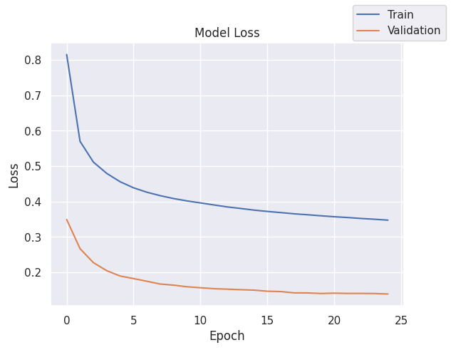

```python
plot(history,'loss')
```

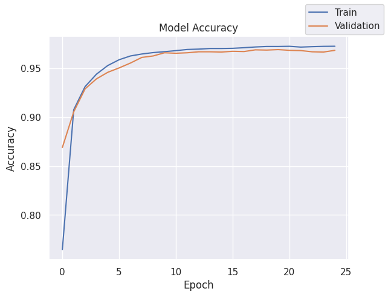

```python
plot(history,'accuracy')
```

```python
model_2_train_perf = model_performance_classification(model, X_train, y_train)
model_2_train_perf
```

```
500/500 ━━━━━━━━━━━━━━━━━━━━ 1s 1ms/step
```

|  | Accuracy | Recall | Precision | F1 Score |
| --- | --- | --- | --- | --- |
| 0 | 0.968562 | 0.968562 | 0.975961 | 0.97096 |

```python
model_2_valid_perf = model_performance_classification(model, X_valid, y_valid)
model_2_valid_perf
```

```
125/125 ━━━━━━━━━━━━━━━━━━━━ 0s 1ms/step
```

|  | Accuracy | Recall | Precision | F1 Score |
| --- | --- | --- | --- | --- |
| 0 | 0.9685 | 0.9685 | 0.976179 | 0.970965 |

```python
results.loc[2] = [2,str([14,7]),str(["relu","relu"]),25,64,"Adam",str([0.001, "-"]),"xavier","-",history.history["loss"][-1],history.history["val_loss"][-1],history.history["accuracy"][-1],history.history["val_accuracy"][-1],round(end-start,2)]
```

```python
results
```

|  | # hidden layers | # neurons - hidden layer | activation function - hidden layer | # epochs | batch size | optimizer | learning rate, momentum | weight initializer | regularization | train loss | validation loss | train accuracy | validation accuracy | time (secs) |
| --- | --- | --- | --- | --- | --- | --- | --- | --- | --- | --- | --- | --- | --- | --- |
| 0 | 2 | [14, 7] | ['relu', 'relu'] | 25 | 64 | sgd | [0.001, '-'] | xavier | - | 0.357475 | 0.152401 | 0.973375 | 0.9690 | 36.58 |
| 1 | 2 | [14, 7] | ['relu', 'relu'] | 25 | 64 | sgd with momentum | [0.001, 0.9] | xavier | - | 0.320486 | 0.144340 | 0.975187 | 0.9685 | 32.60 |
| 2 | 2 | [14, 7] | ['relu', 'relu'] | 25 | 64 | Adam | [0.001, '-'] | xavier | - | 0.347200 | 0.138396 | 0.972687 | 0.9685 | 31.83 |

- Model 2, which uses the Adam optimizer, shows very consistent performance between the training and validation datasets, similar to Model 0.
- The accuracy, recall, precision, and F1 scores are high for both the training and validation sets, indicating good overall performance and generalization.
- Compared to Model 0, Model 2 has slightly lower training accuracy but very similar validation performance across all metrics.
- Compared to Model 1 (with SGD and momentum), Model 2 has slightly lower training metrics but slightly better and more stable validation performance, as seen in the loss and accuracy plots. The validation loss and accuracy curves for Model 2 are smoother than those for Model 1.
- The Adam optimizer seems to provide a good balance between convergence speed and stability for this network architecture.

### Model 3

- The difference between the train loss and test loss is high.
- Let's add dropout to regularize it.

```python
# clears the current Keras session, resetting all layers and models previously created, freeing up memory and resources.
tf.keras.backend.clear_session()
```

```python
#Initializing the neural network
model = Sequential()
model.add(Dense(14,activation="relu",input_dim=X_train.shape[1]))
model.add(Dropout(0.4))
model.add(Dense(7,activation="relu"))
model.add(Dropout(0.2))
model.add(Dense(1,activation="sigmoid"))
```

```python
model.summary()
```

```
Model: "sequential"
```

```
┏━━━━━━━━━━━━━━━━━━━━━━━━━━━━━━━━━┳━━━━━━━━━━━━━━━━━━━━━━━━┳━━━━━━━━━━━━━━━┓
┃ Layer (type)                    ┃ Output Shape           ┃       Param # ┃
┡━━━━━━━━━━━━━━━━━━━━━━━━━━━━━━━━━╇━━━━━━━━━━━━━━━━━━━━━━━━╇━━━━━━━━━━━━━━━┩
│ dense (Dense)                   │ (None, 14)             │           574 │
├─────────────────────────────────┼────────────────────────┼───────────────┤
│ dropout (Dropout)               │ (None, 14)             │             0 │
├─────────────────────────────────┼────────────────────────┼───────────────┤
│ dense_1 (Dense)                 │ (None, 7)              │           105 │
├─────────────────────────────────┼────────────────────────┼───────────────┤
│ dropout_1 (Dropout)             │ (None, 7)              │             0 │
├─────────────────────────────────┼────────────────────────┼───────────────┤
│ dense_2 (Dense)                 │ (None, 1)              │             8 │
└─────────────────────────────────┴────────────────────────┴───────────────┘
```

```
 Total params: 687 (2.68 KB)
```

```
 Trainable params: 687 (2.68 KB)
```

```
 Non-trainable params: 0 (0.00 B)
```

```python
optimizer = tf.keras.optimizers.Adam()    # defining Adam as the optimizer to be used
model.compile(loss='binary_crossentropy', optimizer=optimizer, metrics=['accuracy'])
```

```python
start = time.time()
history = model.fit(X_train, y_train, validation_data=(X_valid,y_valid) , batch_size=batch_size, epochs=epochs,class_weight=cw_dict)
end=time.time()
```

```
250/250 ━━━━━━━━━━━━━━━━━━━━ 3s 4ms/step - accuracy: 0.6708 - loss: 1.3131 - val_accuracy: 0.7567 - val_loss: 0.4823
250/250 ━━━━━━━━━━━━━━━━━━━━ 1s 4ms/step - accuracy: 0.7078 - loss: 1.0554 - val_accuracy: 0.8625 - val_loss: 0.3692
250/250 ━━━━━━━━━━━━━━━━━━━━ 1s 3ms/step - accuracy: 0.7988 - loss: 0.9112 - val_accuracy: 0.8942 - val_loss: 0.3135
250/250 ━━━━━━━━━━━━━━━━━━━━ 1s 3ms/step - accuracy: 0.8252 - loss: 0.8498 - val_accuracy: 0.9130 - val_loss: 0.2841
250/250 ━━━━━━━━━━━━━━━━━━━━ 1s 4ms/step - accuracy: 0.8471 - loss: 0.7828 - val_accuracy: 0.9237 - val_loss: 0.2636
250/250 ━━━━━━━━━━━━━━━━━━━━ 1s 3ms/step - accuracy: 0.8604 - loss: 0.7374 - val_accuracy: 0.9335 - val_loss: 0.2550
250/250 ━━━━━━━━━━━━━━━━━━━━ 1s 3ms/step - accuracy: 0.8752 - loss: 0.7276 - val_accuracy: 0.9445 - val_loss: 0.2402
250/250 ━━━━━━━━━━━━━━━━━━━━ 1s 3ms/step - accuracy: 0.8932 - loss: 0.7055 - val_accuracy: 0.9477 - val_loss: 0.2347
250/250 ━━━━━━━━━━━━━━━━━━━━ 2s 5ms/step - accuracy: 0.8986 - loss: 0.7086 - val_accuracy: 0.9473 - val_loss: 0.2403
250/250 ━━━━━━━━━━━━━━━━━━━━ 2s 6ms/step - accuracy: 0.9048 - loss: 0.6610 - val_accuracy: 0.9513 - val_loss: 0.2319
250/250 ━━━━━━━━━━━━━━━━━━━━ 1s 6ms/step - accuracy: 0.9085 - loss: 0.6446 - val_accuracy: 0.9517 - val_loss: 0.2245
250/250 ━━━━━━━━━━━━━━━━━━━━ 2s 3ms/step - accuracy: 0.9110 - loss: 0.6364 - val_accuracy: 0.9555 - val_loss: 0.2112
250/250 ━━━━━━━━━━━━━━━━━━━━ 1s 3ms/step - accuracy: 0.9185 - loss: 0.6382 - val_accuracy: 0.9545 - val_loss: 0.2205
250/250 ━━━━━━━━━━━━━━━━━━━━ 1s 3ms/step - accuracy: 0.9187 - loss: 0.6463 - val_accuracy: 0.9563 - val_loss: 0.2202
250/250 ━━━━━━━━━━━━━━━━━━━━ 1s 3ms/step - accuracy: 0.9223 - loss: 0.6103 - val_accuracy: 0.9495 - val_loss: 0.2293
250/250 ━━━━━━━━━━━━━━━━━━━━ 1s 3ms/step - accuracy: 0.9220 - loss: 0.6209 - val_accuracy: 0.9588 - val_loss: 0.2128
250/250 ━━━━━━━━━━━━━━━━━━━━ 1s 3ms/step - accuracy: 0.9262 - loss: 0.6039 - val_accuracy: 0.9542 - val_loss: 0.2157
250/250 ━━━━━━━━━━━━━━━━━━━━ 1s 3ms/step - accuracy: 0.9251 - loss: 0.6273 - val_accuracy: 0.9525 - val_loss: 0.2175
250/250 ━━━━━━━━━━━━━━━━━━━━ 1s 3ms/step - accuracy: 0.9241 - loss: 0.6027 - val_accuracy: 0.9565 - val_loss: 0.2112
250/250 ━━━━━━━━━━━━━━━━━━━━ 2s 5ms/step - accuracy: 0.9199 - loss: 0.6218 - val_accuracy: 0.9600 - val_loss: 0.2134
250/250 ━━━━━━━━━━━━━━━━━━━━ 1s 6ms/step - accuracy: 0.9298 - loss: 0.5893 - val_accuracy: 0.9578 - val_loss: 0.2123
250/250 ━━━━━━━━━━━━━━━━━━━━ 1s 6ms/step - accuracy: 0.9314 - loss: 0.6038 - val_accuracy: 0.9550 - val_loss: 0.2111
250/250 ━━━━━━━━━━━━━━━━━━━━ 2s 3ms/step - accuracy: 0.9265 - loss: 0.5947 - val_accuracy: 0.9590 - val_loss: 0.2065
250/250 ━━━━━━━━━━━━━━━━━━━━ 1s 4ms/step - accuracy: 0.9335 - loss: 0.5862 - val_accuracy: 0.9605 - val_loss: 0.2030
250/250 ━━━━━━━━━━━━━━━━━━━━ 1s 4ms/step - accuracy: 0.9344 - loss: 0.5711 - val_accuracy: 0.9580 - val_loss: 0.1966
```

```python
print("Time taken in seconds ",end-start)
```

```
Time taken in seconds  34.36256957054138
```

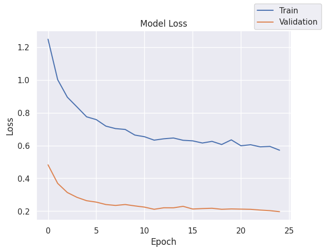

```python
plot(history,'loss')
```

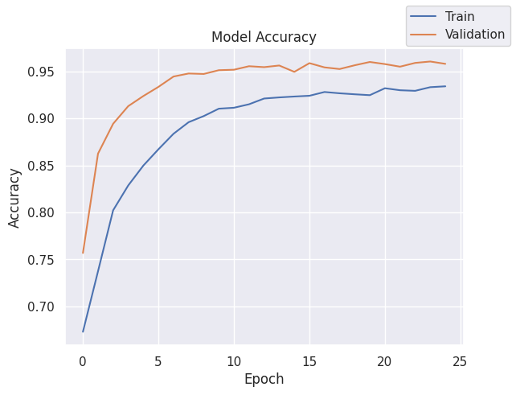

```python
plot(history,'accuracy')
```

```python
model_3_train_perf = model_performance_classification(model, X_train, y_train)
model_3_train_perf
```

```
500/500 ━━━━━━━━━━━━━━━━━━━━ 1s 1ms/step
```

|  | Accuracy | Recall | Precision | F1 Score |
| --- | --- | --- | --- | --- |
| 0 | 0.954187 | 0.954187 | 0.968798 | 0.959064 |

```python
model_3_valid_perf = model_performance_classification(model, X_valid, y_valid)
model_3_valid_perf
```

```
125/125 ━━━━━━━━━━━━━━━━━━━━ 0s 1ms/step
```

|  | Accuracy | Recall | Precision | F1 Score |
| --- | --- | --- | --- | --- |
| 0 | 0.958 | 0.958 | 0.971125 | 0.962286 |

```python
results.loc[3] = [2,str([14,7]),str(["relu","relu"]),25,64,"Adam",str([0.001, "-"]),"xavier","dropout(0.4, 0.2)",history.history["loss"][-1],history.history["val_loss"][-1],history.history["accuracy"][-1],history.history["val_accuracy"][-1],round(end-start,2)]
```

```python
results
```

|  | # hidden layers | # neurons - hidden layer | activation function - hidden layer | # epochs | batch size | optimizer | learning rate, momentum | weight initializer | regularization | train loss | validation loss | train accuracy | validation accuracy | time (secs) |
| --- | --- | --- | --- | --- | --- | --- | --- | --- | --- | --- | --- | --- | --- | --- |
| 0 | 2 | [14, 7] | ['relu', 'relu'] | 25 | 64 | sgd | [0.001, '-'] | xavier | - | 0.357475 | 0.152401 | 0.973375 | 0.96900 | 36.58 |
| 1 | 2 | [14, 7] | ['relu', 'relu'] | 25 | 64 | sgd with momentum | [0.001, 0.9] | xavier | - | 0.320486 | 0.144340 | 0.975187 | 0.96850 | 32.60 |
| 2 | 2 | [14, 7] | ['relu', 'relu'] | 25 | 64 | Adam | [0.001, '-'] | xavier | - | 0.347200 | 0.138396 | 0.972687 | 0.96850 | 31.83 |
| 3 | 2 | [14, 7] | ['relu', 'relu'] | 25 | 64 | Adam | [0.001, '-'] | xavier | dropout(0.4, 0.2) | 0.571548 | 0.196581 | 0.934125 | 0.95800 | 34.36 |
| 4 | 2 | [14, 7] | ['relu', 'relu'] | 25 | 64 | Adam | [0.001, '-'] | xavier | - | 0.532666 | 0.171215 | 0.942937 | 0.98100 | 33.15 |
| 5 | 2 | [14, 7] | ['relu', 'relu'] | 25 | 64 | Adam | [0.001, '-'] | xavier | dropout(0.4, 0.2) | 0.617260 | 0.192033 | 0.917375 | 0.96075 | 44.72 |
| 6 | 2 | [128, 64] | ['relu', 'relu'] | 25 | 64 | Adam | [0.001, '-'] | he_normal | dropout(0.4, 0.2) | 0.319370 | 0.118356 | 0.980062 | 0.98850 | 36.59 |
| 7 | 2 | [128, 64] | ['relu', 'relu'] | 25 | 64 | Adam | [0.001, '-'] | he_normal | dropout(0.4, 0.2) | 0.246631 | 0.101820 | 0.980625 | 0.98750 | 38.43 |

### Model 4

- The scores are still not that good.
- Let's add batch normalization to see whether we can stabilize the training process and thereby improve the scores.

```python
# clears the current Keras session, resetting all layers and models previously created, freeing up memory and resources.
tf.keras.backend.clear_session()
```

```python
#Initializing the neural network
model = Sequential()
model.add(Dense(14,activation="relu",input_dim=X_train.shape[1]))
model.add(BatchNormalization())
model.add(Dense(7,activation="relu"))
model.add(BatchNormalization())
model.add(Dense(1,activation="sigmoid"))
```

```python
model.summary()
```

```
Model: "sequential"
```

```
┏━━━━━━━━━━━━━━━━━━━━━━━━━━━━━━━━━┳━━━━━━━━━━━━━━━━━━━━━━━━┳━━━━━━━━━━━━━━━┓
┃ Layer (type)                    ┃ Output Shape           ┃       Param # ┃
┡━━━━━━━━━━━━━━━━━━━━━━━━━━━━━━━━━╇━━━━━━━━━━━━━━━━━━━━━━━━╇━━━━━━━━━━━━━━━┩
│ dense (Dense)                   │ (None, 14)             │           574 │
├─────────────────────────────────┼────────────────────────┼───────────────┤
│ batch_normalization             │ (None, 14)             │            56 │
│ (BatchNormalization)            │                        │               │
├─────────────────────────────────┼────────────────────────┼───────────────┤
│ dense_1 (Dense)                 │ (None, 7)              │           105 │
├─────────────────────────────────┼────────────────────────┼───────────────┤
│ batch_normalization_1           │ (None, 7)              │            28 │
│ (BatchNormalization)            │                        │               │
├─────────────────────────────────┼────────────────────────┼───────────────┤
│ dense_2 (Dense)                 │ (None, 1)              │             8 │
└─────────────────────────────────┴────────────────────────┴───────────────┘
```

```
 Total params: 771 (3.01 KB)
```

```
 Trainable params: 729 (2.85 KB)
```

```
 Non-trainable params: 42 (168.00 B)
```

```python
optimizer = tf.keras.optimizers.Adam()    # defining Adam as the optimizer to be used
model.compile(loss='binary_crossentropy', optimizer=optimizer, metrics=['accuracy'])
```

```python
start = time.time()
history = model.fit(X_train, y_train, validation_data=(X_valid,y_valid) , batch_size=batch_size, epochs=epochs,class_weight=cw_dict)
end=time.time()
```

```
250/250 ━━━━━━━━━━━━━━━━━━━━ 5s 7ms/step - accuracy: 0.6915 - loss: 1.0645 - val_accuracy: 0.9090 - val_loss: 0.3788
250/250 ━━━━━━━━━━━━━━━━━━━━ 2s 4ms/step - accuracy: 0.8716 - loss: 0.6468 - val_accuracy: 0.9448 - val_loss: 0.2515
250/250 ━━━━━━━━━━━━━━━━━━━━ 1s 4ms/step - accuracy: 0.9266 - loss: 0.5341 - val_accuracy: 0.9517 - val_loss: 0.2159
250/250 ━━━━━━━━━━━━━━━━━━━━ 1s 4ms/step - accuracy: 0.9471 - loss: 0.4790 - val_accuracy: 0.9560 - val_loss: 0.1973
250/250 ━━━━━━━━━━━━━━━━━━━━ 1s 4ms/step - accuracy: 0.9557 - loss: 0.4397 - val_accuracy: 0.9672 - val_loss: 0.1718
250/250 ━━━━━━━━━━━━━━━━━━━━ 1s 4ms/step - accuracy: 0.9617 - loss: 0.4124 - val_accuracy: 0.9693 - val_loss: 0.1571
250/250 ━━━━━━━━━━━━━━━━━━━━ 1s 4ms/step - accuracy: 0.9625 - loss: 0.3987 - val_accuracy: 0.9703 - val_loss: 0.1510
250/250 ━━━━━━━━━━━━━━━━━━━━ 1s 4ms/step - accuracy: 0.9649 - loss: 0.3878 - val_accuracy: 0.9745 - val_loss: 0.1421
250/250 ━━━━━━━━━━━━━━━━━━━━ 1s 4ms/step - accuracy: 0.9665 - loss: 0.3780 - val_accuracy: 0.9730 - val_loss: 0.1404
250/250 ━━━━━━━━━━━━━━━━━━━━ 2s 6ms/step - accuracy: 0.9683 - loss: 0.3748 - val_accuracy: 0.9755 - val_loss: 0.1346
250/250 ━━━━━━━━━━━━━━━━━━━━ 2s 6ms/step - accuracy: 0.9682 - loss: 0.3723 - val_accuracy: 0.9770 - val_loss: 0.1313
250/250 ━━━━━━━━━━━━━━━━━━━━ 2s 4ms/step - accuracy: 0.9687 - loss: 0.3678 - val_accuracy: 0.9772 - val_loss: 0.1288
250/250 ━━━━━━━━━━━━━━━━━━━━ 1s 4ms/step - accuracy: 0.9683 - loss: 0.3672 - val_accuracy: 0.9772 - val_loss: 0.1298
250/250 ━━━━━━━━━━━━━━━━━━━━ 1s 4ms/step - accuracy: 0.9695 - loss: 0.3620 - val_accuracy: 0.9795 - val_loss: 0.1271
250/250 ━━━━━━━━━━━━━━━━━━━━ 1s 4ms/step - accuracy: 0.9692 - loss: 0.3550 - val_accuracy: 0.9793 - val_loss: 0.1249
250/250 ━━━━━━━━━━━━━━━━━━━━ 1s 4ms/step - accuracy: 0.9692 - loss: 0.3534 - val_accuracy: 0.9780 - val_loss: 0.1254
250/250 ━━━━━━━━━━━━━━━━━━━━ 1s 4ms/step - accuracy: 0.9695 - loss: 0.3489 - val_accuracy: 0.9772 - val_loss: 0.1238
250/250 ━━━━━━━━━━━━━━━━━━━━ 1s 4ms/step - accuracy: 0.9695 - loss: 0.3455 - val_accuracy: 0.9805 - val_loss: 0.1183
250/250 ━━━━━━━━━━━━━━━━━━━━ 2s 5ms/step - accuracy: 0.9711 - loss: 0.3427 - val_accuracy: 0.9797 - val_loss: 0.1179
250/250 ━━━━━━━━━━━━━━━━━━━━ 3s 6ms/step - accuracy: 0.9707 - loss: 0.3364 - val_accuracy: 0.9797 - val_loss: 0.1164
250/250 ━━━━━━━━━━━━━━━━━━━━ 2s 4ms/step - accuracy: 0.9714 - loss: 0.3330 - val_accuracy: 0.9803 - val_loss: 0.1150
250/250 ━━━━━━━━━━━━━━━━━━━━ 1s 4ms/step - accuracy: 0.9721 - loss: 0.3315 - val_accuracy: 0.9808 - val_loss: 0.1128
250/250 ━━━━━━━━━━━━━━━━━━━━ 1s 4ms/step - accuracy: 0.9723 - loss: 0.3325 - val_accuracy: 0.9815 - val_loss: 0.1118
250/250 ━━━━━━━━━━━━━━━━━━━━ 1s 4ms/step - accuracy: 0.9724 - loss: 0.3304 - val_accuracy: 0.9800 - val_loss: 0.1124
250/250 ━━━━━━━━━━━━━━━━━━━━ 1s 4ms/step - accuracy: 0.9727 - loss: 0.3279 - val_accuracy: 0.9810 - val_loss: 0.1111
```

```python
print("Time taken in seconds ",end-start)
```

```
Time taken in seconds  38.75756120681763
```

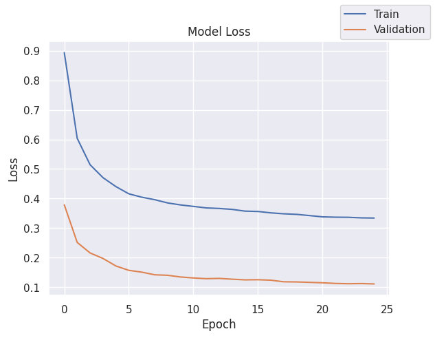

```python
plot(history,'loss')
```

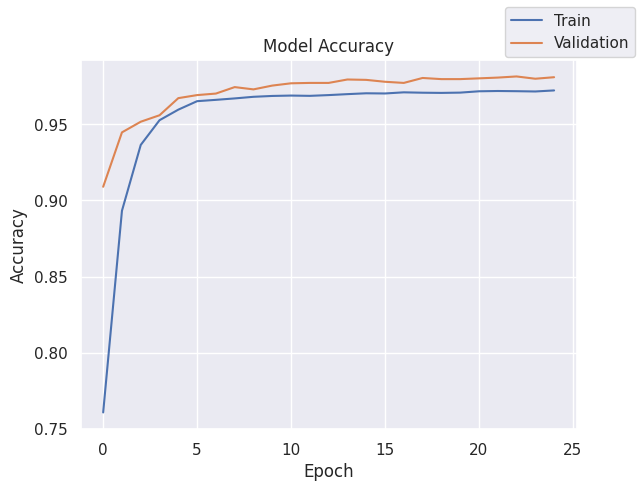

```python
plot(history,'accuracy')
```

```python
model_4_train_perf = model_performance_classification(model, X_train, y_train)
model_4_train_perf
```

```
500/500 ━━━━━━━━━━━━━━━━━━━━ 1s 1ms/step
```

|  | Accuracy | Recall | Precision | F1 Score |
| --- | --- | --- | --- | --- |
| 0 | 0.981938 | 0.981938 | 0.983461 | 0.982486 |

```python
model_4_valid_perf = model_performance_classification(model, X_valid, y_valid)
model_4_valid_perf
```

```
125/125 ━━━━━━━━━━━━━━━━━━━━ 0s 1ms/step
```

|  | Accuracy | Recall | Precision | F1 Score |
| --- | --- | --- | --- | --- |
| 0 | 0.981 | 0.981 | 0.982778 | 0.981633 |

```python
results.loc[4] = [2,str([14,7]),str(["relu","relu"]),25,64,"Adam",str([0.001, "-"]),"xavier","-",history.history["loss"][-1],history.history["val_loss"][-1],history.history["accuracy"][-1],history.history["val_accuracy"][-1],round(end-start,2)]
```

```python
results
```

|  | # hidden layers | # neurons - hidden layer | activation function - hidden layer | # epochs | batch size | optimizer | learning rate, momentum | weight initializer | regularization | train loss | validation loss | train accuracy | validation accuracy | time (secs) |
| --- | --- | --- | --- | --- | --- | --- | --- | --- | --- | --- | --- | --- | --- | --- |
| 0 | 2 | [14, 7] | ['relu', 'relu'] | 25 | 64 | sgd | [0.001, '-'] | xavier | - | 0.357475 | 0.152401 | 0.973375 | 0.96900 | 36.58 |
| 1 | 2 | [14, 7] | ['relu', 'relu'] | 25 | 64 | sgd with momentum | [0.001, 0.9] | xavier | - | 0.320486 | 0.144340 | 0.975187 | 0.96850 | 32.60 |
| 2 | 2 | [14, 7] | ['relu', 'relu'] | 25 | 64 | Adam | [0.001, '-'] | xavier | - | 0.347200 | 0.138396 | 0.972687 | 0.96850 | 31.83 |
| 3 | 2 | [14, 7] | ['relu', 'relu'] | 25 | 64 | Adam | [0.001, '-'] | xavier | dropout(0.4, 0.2) | 0.334023 | 0.111131 | 0.972313 | 0.98100 | 38.76 |
| 4 | 2 | [14, 7] | ['relu', 'relu'] | 25 | 64 | Adam | [0.001, '-'] | xavier | - | 0.532666 | 0.171215 | 0.942937 | 0.98100 | 33.15 |
| 5 | 2 | [14, 7] | ['relu', 'relu'] | 25 | 64 | Adam | [0.001, '-'] | xavier | dropout(0.4, 0.2) | 0.617260 | 0.192033 | 0.917375 | 0.96075 | 44.72 |
| 6 | 2 | [14, 7] | ['relu', 'relu'] | 25 | 64 | Adam | [0.001, '-'] | he_normal | dropout(0.4, 0.2) | 0.532666 | 0.171215 | 0.942937 | 0.98100 | 33.15 |

### Model 5

- Let's add both batchnormalization and dropout.

```python
# clears the current Keras session, resetting all layers and models previously created, freeing up memory and resources.
tf.keras.backend.clear_session()
```

```python
#Initializing the neural network
model = Sequential()
model.add(Dense(14,activation="relu",input_dim=X_train.shape[1]))
model.add(BatchNormalization())
model.add(Dropout(0.4))
model.add(Dense(7,activation="relu"))
model.add(BatchNormalization())
model.add(Dropout(0.2))
model.add(Dense(1,activation="sigmoid"))
```

```python
model.summary()
```

```
Model: "sequential"
```

```
┏━━━━━━━━━━━━━━━━━━━━━━━━━━━━━━━━━┳━━━━━━━━━━━━━━━━━━━━━━━━┳━━━━━━━━━━━━━━━┓
┃ Layer (type)                    ┃ Output Shape           ┃       Param # ┃
┡━━━━━━━━━━━━━━━━━━━━━━━━━━━━━━━━━╇━━━━━━━━━━━━━━━━━━━━━━━━╇━━━━━━━━━━━━━━━┩
│ dense (Dense)                   │ (None, 14)             │           574 │
├─────────────────────────────────┼────────────────────────┼───────────────┤
│ batch_normalization             │ (None, 14)             │            56 │
│ (BatchNormalization)            │                        │               │
├─────────────────────────────────┼────────────────────────┼───────────────┤
│ dropout (Dropout)               │ (None, 14)             │             0 │
├─────────────────────────────────┼────────────────────────┼───────────────┤
│ dense_1 (Dense)                 │ (None, 7)              │           105 │
├─────────────────────────────────┼────────────────────────┼───────────────┤
│ batch_normalization_1           │ (None, 7)              │            28 │
│ (BatchNormalization)            │                        │               │
├─────────────────────────────────┼────────────────────────┼───────────────┤
│ dropout_1 (Dropout)             │ (None, 7)              │             0 │
├─────────────────────────────────┼────────────────────────┼───────────────┤
│ dense_2 (Dense)                 │ (None, 1)              │             8 │
└─────────────────────────────────┴────────────────────────┴───────────────┘
```

```
 Total params: 771 (3.01 KB)
```

```
 Trainable params: 729 (2.85 KB)
```

```
 Non-trainable params: 42 (168.00 B)
```

```python
optimizer = tf.keras.optimizers.Adam()    # defining Adam as the optimizer to be used
model.compile(loss='binary_crossentropy', optimizer=optimizer, metrics=['accuracy'])
```

```python
start = time.time()
history = model.fit(X_train, y_train, validation_data=(X_valid,y_valid) , batch_size=batch_size, epochs=epochs,class_weight=cw_dict)
end=time.time()
```

```
250/250 ━━━━━━━━━━━━━━━━━━━━ 11s 18ms/step - accuracy: 0.4316 - loss: 1.6070 - val_accuracy: 0.6683 - val_loss: 0.5840
250/250 ━━━━━━━━━━━━━━━━━━━━ 2s 7ms/step - accuracy: 0.6607 - loss: 1.0922 - val_accuracy: 0.8055 - val_loss: 0.4681
250/250 ━━━━━━━━━━━━━━━━━━━━ 2s 4ms/step - accuracy: 0.7735 - loss: 0.9432 - val_accuracy: 0.8618 - val_loss: 0.3843
250/250 ━━━━━━━━━━━━━━━━━━━━ 1s 4ms/step - accuracy: 0.8243 - loss: 0.8804 - val_accuracy: 0.8895 - val_loss: 0.3328
250/250 ━━━━━━━━━━━━━━━━━━━━ 1s 4ms/step - accuracy: 0.8567 - loss: 0.8088 - val_accuracy: 0.9047 - val_loss: 0.2983
250/250 ━━━━━━━━━━━━━━━━━━━━ 1s 4ms/step - accuracy: 0.8692 - loss: 0.7620 - val_accuracy: 0.9060 - val_loss: 0.2889
250/250 ━━━━━━━━━━━━━━━━━━━━ 2s 5ms/step - accuracy: 0.8817 - loss: 0.7252 - val_accuracy: 0.9197 - val_loss: 0.2650
250/250 ━━━━━━━━━━━━━━━━━━━━ 2s 7ms/step - accuracy: 0.8779 - loss: 0.7368 - val_accuracy: 0.9162 - val_loss: 0.2645
250/250 ━━━━━━━━━━━━━━━━━━━━ 2s 6ms/step - accuracy: 0.8816 - loss: 0.6951 - val_accuracy: 0.9165 - val_loss: 0.2551
250/250 ━━━━━━━━━━━━━━━━━━━━ 1s 4ms/step - accuracy: 0.8864 - loss: 0.7260 - val_accuracy: 0.9168 - val_loss: 0.2566
250/250 ━━━━━━━━━━━━━━━━━━━━ 1s 4ms/step - accuracy: 0.8886 - loss: 0.7020 - val_accuracy: 0.9298 - val_loss: 0.2393
250/250 ━━━━━━━━━━━━━━━━━━━━ 1s 5ms/step - accuracy: 0.8958 - loss: 0.6945 - val_accuracy: 0.9415 - val_loss: 0.2223
250/250 ━━━━━━━━━━━━━━━━━━━━ 1s 4ms/step - accuracy: 0.8985 - loss: 0.6799 - val_accuracy: 0.9457 - val_loss: 0.2142
250/250 ━━━━━━━━━━━━━━━━━━━━ 1s 4ms/step - accuracy: 0.9077 - loss: 0.6253 - val_accuracy: 0.9495 - val_loss: 0.2112
250/250 ━━━━━━━━━━━━━━━━━━━━ 1s 5ms/step - accuracy: 0.9101 - loss: 0.6259 - val_accuracy: 0.9430 - val_loss: 0.2146
250/250 ━━━━━━━━━━━━━━━━━━━━ 1s 4ms/step - accuracy: 0.9018 - loss: 0.6418 - val_accuracy: 0.9500 - val_loss: 0.2062
250/250 ━━━━━━━━━━━━━━━━━━━━ 1s 4ms/step - accuracy: 0.9113 - loss: 0.6074 - val_accuracy: 0.9523 - val_loss: 0.2016
250/250 ━━━━━━━━━━━━━━━━━━━━ 2s 6ms/step - accuracy: 0.9121 - loss: 0.6162 - val_accuracy: 0.9617 - val_loss: 0.1884
250/250 ━━━━━━━━━━━━━━━━━━━━ 3s 6ms/step - accuracy: 0.9115 - loss: 0.6149 - val_accuracy: 0.9452 - val_loss: 0.2057
250/250 ━━━━━━━━━━━━━━━━━━━━ 1s 4ms/step - accuracy: 0.9131 - loss: 0.6181 - val_accuracy: 0.9427 - val_loss: 0.2109
250/250 ━━━━━━━━━━━━━━━━━━━━ 1s 5ms/step - accuracy: 0.9070 - loss: 0.6201 - val_accuracy: 0.9605 - val_loss: 0.1848
250/250 ━━━━━━━━━━━━━━━━━━━━ 2s 6ms/step - accuracy: 0.9180 - loss: 0.5936 - val_accuracy: 0.9523 - val_loss: 0.2007
250/250 ━━━━━━━━━━━━━━━━━━━━ 2s 5ms/step - accuracy: 0.9114 - loss: 0.6269 - val_accuracy: 0.9560 - val_loss: 0.1968
250/250 ━━━━━━━━━━━━━━━━━━━━ 1s 4ms/step - accuracy: 0.9170 - loss: 0.5966 - val_accuracy: 0.9605 - val_loss: 0.1892
250/250 ━━━━━━━━━━━━━━━━━━━━ 1s 4ms/step - accuracy: 0.9127 - loss: 0.6168 - val_accuracy: 0.9607 - val_loss: 0.1920
```

```python
print("Time taken in seconds ",end-start)
```

```
Time taken in seconds  44.72055387496948
```

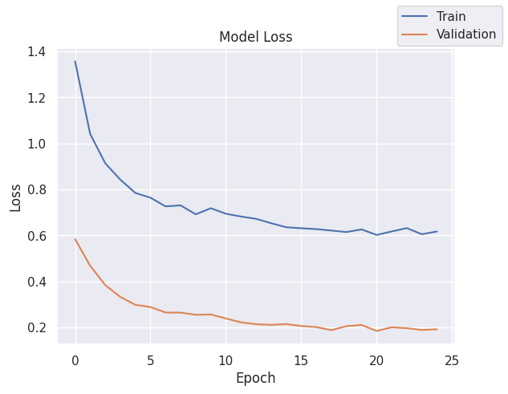

```python
plot(history,'loss')
```

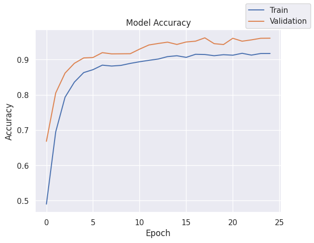

```python
plot(history,'accuracy')
```

```python
model_5_train_perf = model_performance_classification(model, X_train, y_train)
model_5_train_perf
```

```
500/500 ━━━━━━━━━━━━━━━━━━━━ 1s 2ms/step
```

|  | Accuracy | Recall | Precision | F1 Score |
| --- | --- | --- | --- | --- |
| 0 | 0.952875 | 0.952875 | 0.968401 | 0.958051 |

```python
model_5_valid_perf = model_performance_classification(model, X_valid, y_valid)
model_5_valid_perf
```

```
125/125 ━━━━━━━━━━━━━━━━━━━━ 0s 2ms/step
```

|  | Accuracy | Recall | Precision | F1 Score |
| --- | --- | --- | --- | --- |
| 0 | 0.96075 | 0.96075 | 0.97286 | 0.964633 |

```python
results.loc[5] = [2,str([14,7]),str(["relu","relu"]),25,64,"Adam",str([0.001, "-"]),"xavier","dropout(0.4, 0.2)",history.history["loss"][-1],history.history["val_loss"][-1],history.history["accuracy"][-1],history.history["val_accuracy"][-1],round(end-start,2)]
```

```python
results
```

|  | # hidden layers | # neurons - hidden layer | activation function - hidden layer | # epochs | batch size | optimizer | learning rate, momentum | weight initializer | regularization | train loss | validation loss | train accuracy | validation accuracy | time (secs) |
| --- | --- | --- | --- | --- | --- | --- | --- | --- | --- | --- | --- | --- | --- | --- |
| 0 | 2 | [14, 7] | ['relu', 'relu'] | 25 | 64 | sgd | [0.001, '-'] | xavier | - | 0.357475 | 0.152401 | 0.973375 | 0.96900 | 36.58 |
| 1 | 2 | [14, 7] | ['relu', 'relu'] | 25 | 64 | sgd with momentum | [0.001, 0.9] | xavier | - | 0.320486 | 0.144340 | 0.975187 | 0.96850 | 32.60 |
| 2 | 2 | [14, 7] | ['relu', 'relu'] | 25 | 64 | Adam | [0.001, '-'] | xavier | - | 0.347200 | 0.138396 | 0.972687 | 0.96850 | 31.83 |
| 3 | 2 | [14, 7] | ['relu', 'relu'] | 25 | 64 | Adam | [0.001, '-'] | xavier | dropout(0.4, 0.2) | 0.334023 | 0.111131 | 0.972313 | 0.98100 | 38.76 |
| 4 | 2 | [14, 7] | ['relu', 'relu'] | 25 | 64 | Adam | [0.001, '-'] | xavier | dropout(0.4, 0.2) | 0.334023 | 0.111131 | 0.972313 | 0.98100 | 38.76 |
| 5 | 2 | [14, 7] | ['relu', 'relu'] | 25 | 64 | Adam | [0.001, '-'] | xavier | dropout(0.4, 0.2) | 0.617260 | 0.192033 | 0.917375 | 0.96075 | 44.72 |

There is a slight decrease in the performance matrics

### Model 6

- Let's initialize the weights using He normal.
- We'll also use only Dropout for regularization.

```python
# clears the current Keras session, resetting all layers and models previously created, freeing up memory and resources.
tf.keras.backend.clear_session()
```

```python
#Initializing the neural network
model = Sequential()
model.add(Dense(14,activation="relu",kernel_initializer="he_normal",input_dim=X_train.shape[1]))
model.add(Dropout(0.4))
model.add(Dense(7,activation="relu",kernel_initializer="he_normal"))
model.add(Dropout(0.2))
model.add(Dense(1,activation="sigmoid",kernel_initializer="he_normal"))
```

```python
model.summary()
```

```
Model: "sequential"
```

```
┏━━━━━━━━━━━━━━━━━━━━━━━━━━━━━━━━━┳━━━━━━━━━━━━━━━━━━━━━━━━┳━━━━━━━━━━━━━━━┓
┃ Layer (type)                    ┃ Output Shape           ┃       Param # ┃
┡━━━━━━━━━━━━━━━━━━━━━━━━━━━━━━━━━╇━━━━━━━━━━━━━━━━━━━━━━━━╇━━━━━━━━━━━━━━━┩
│ dense (Dense)                   │ (None, 14)             │           574 │
├─────────────────────────────────┼────────────────────────┼───────────────┤
│ dropout (Dropout)               │ (None, 14)             │             0 │
├─────────────────────────────────┼────────────────────────┼───────────────┤
│ dense_1 (Dense)                 │ (None, 7)              │           105 │
├─────────────────────────────────┼────────────────────────┼───────────────┤
│ dropout_1 (Dropout)             │ (None, 7)              │             0 │
├─────────────────────────────────┼────────────────────────┼───────────────┤
│ dense_2 (Dense)                 │ (None, 1)              │             8 │
└─────────────────────────────────┴────────────────────────┴───────────────┘
```

```
 Total params: 687 (2.68 KB)
```

```
 Trainable params: 687 (2.68 KB)
```

```
 Non-trainable params: 0 (0.00 B)
```

```python
optimizer = tf.keras.optimizers.Adam()    # defining Adam as the optimizer to be used
model.compile(loss='binary_crossentropy', optimizer=optimizer, metrics=['accuracy'])
```

```python
start = time.time()
history = model.fit(X_train, y_train, validation_data=(X_valid,y_valid) , batch_size=batch_size, epochs=epochs,class_weight=cw_dict)
end=time.time()
```

```
250/250 ━━━━━━━━━━━━━━━━━━━━ 3s 4ms/step - accuracy: 0.9590 - loss: 0.5475 - val_accuracy: 0.9765 - val_loss: 0.1905
250/250 ━━━━━━━━━━━━━━━━━━━━ 1s 3ms/step - accuracy: 0.9562 - loss: 0.5386 - val_accuracy: 0.9787 - val_loss: 0.1835
250/250 ━━━━━━━━━━━━━━━━━━━━ 1s 3ms/step - accuracy: 0.9544 - loss: 0.5814 - val_accuracy: 0.9768 - val_loss: 0.1959
250/250 ━━━━━━━━━━━━━━━━━━━━ 1s 3ms/step - accuracy: 0.9587 - loss: 0.5297 - val_accuracy: 0.9770 - val_loss: 0.1892
250/250 ━━━━━━━━━━━━━━━━━━━━ 1s 3ms/step - accuracy: 0.9548 - loss: 0.5536 - val_accuracy: 0.9790 - val_loss: 0.1804
250/250 ━━━━━━━━━━━━━━━━━━━━ 1s 3ms/step - accuracy: 0.9524 - loss: 0.5553 - val_accuracy: 0.9762 - val_loss: 0.1869
250/250 ━━━━━━━━━━━━━━━━━━━━ 1s 3ms/step - accuracy: 0.9512 - loss: 0.5458 - val_accuracy: 0.9787 - val_loss: 0.1835
250/250 ━━━━━━━━━━━━━━━━━━━━ 1s 3ms/step - accuracy: 0.9543 - loss: 0.5562 - val_accuracy: 0.9747 - val_loss: 0.1836
250/250 ━━━━━━━━━━━━━━━━━━━━ 2s 5ms/step - accuracy: 0.9482 - loss: 0.5741 - val_accuracy: 0.9743 - val_loss: 0.1892
250/250 ━━━━━━━━━━━━━━━━━━━━ 1s 6ms/step - accuracy: 0.9509 - loss: 0.5580 - val_accuracy: 0.9780 - val_loss: 0.1834
250/250 ━━━━━━━━━━━━━━━━━━━━ 2s 3ms/step - accuracy: 0.9557 - loss: 0.5171 - val_accuracy: 0.9772 - val_loss: 0.1740
250/250 ━━━━━━━━━━━━━━━━━━━━ 1s 3ms/step - accuracy: 0.9546 - loss: 0.5397 - val_accuracy: 0.9790 - val_loss: 0.1738
250/250 ━━━━━━━━━━━━━━━━━━━━ 1s 3ms/step - accuracy: 0.9498 - loss: 0.5585 - val_accuracy: 0.9830 - val_loss: 0.1751
250/250 ━━━━━━━━━━━━━━━━━━━━ 1s 3ms/step - accuracy: 0.9399 - loss: 0.5523 - val_accuracy: 0.9783 - val_loss: 0.1838
250/250 ━━━━━━━━━━━━━━━━━━━━ 1s 3ms/step - accuracy: 0.9517 - loss: 0.5232 - val_accuracy: 0.9787 - val_loss: 0.1852
250/250 ━━━━━━━━━━━━━━━━━━━━ 1s 3ms/step - accuracy: 0.9402 - loss: 0.5581 - val_accuracy: 0.9747 - val_loss: 0.1808
250/250 ━━━━━━━━━━━━━━━━━━━━ 1s 3ms/step - accuracy: 0.9354 - loss: 0.5155 - val_accuracy: 0.9750 - val_loss: 0.1767
250/250 ━━━━━━━━━━━━━━━━━━━━ 1s 3ms/step - accuracy: 0.9359 - loss: 0.5331 - val_accuracy: 0.9765 - val_loss: 0.1770
250/250 ━━━━━━━━━━━━━━━━━━━━ 1s 4ms/step - accuracy: 0.9364 - loss: 0.5491 - val_accuracy: 0.9753 - val_loss: 0.1763
250/250 ━━━━━━━━━━━━━━━━━━━━ 1s 6ms/step - accuracy: 0.9353 - loss: 0.5375 - val_accuracy: 0.9797 - val_loss: 0.1708
250/250 ━━━━━━━━━━━━━━━━━━━━ 3s 6ms/step - accuracy: 0.9349 - loss: 0.5511 - val_accuracy: 0.9830 - val_loss: 0.1709
250/250 ━━━━━━━━━━━━━━━━━━━━ 1s 3ms/step - accuracy: 0.9414 - loss: 0.5113 - val_accuracy: 0.9820 - val_loss: 0.1687
250/250 ━━━━━━━━━━━━━━━━━━━━ 1s 3ms/step - accuracy: 0.9353 - loss: 0.5349 - val_accuracy: 0.9805 - val_loss: 0.1723
250/250 ━━━━━━━━━━━━━━━━━━━━ 1s 3ms/step - accuracy: 0.9395 - loss: 0.5156 - val_accuracy: 0.9843 - val_loss: 0.1632
250/250 ━━━━━━━━━━━━━━━━━━━━ 1s 4ms/step - accuracy: 0.9408 - loss: 0.5358 - val_accuracy: 0.9810 - val_loss: 0.1712
```

```python
print("Time taken in seconds ",end-start)
```

```
Time taken in seconds  33.148128032684326
```

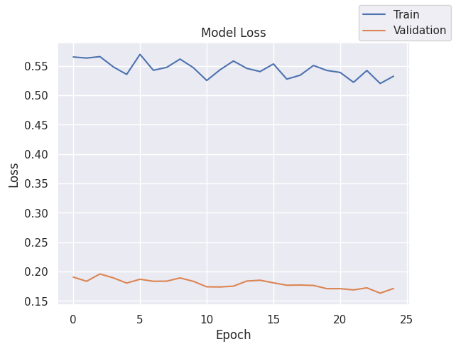

```python
plot(history,'loss')
```

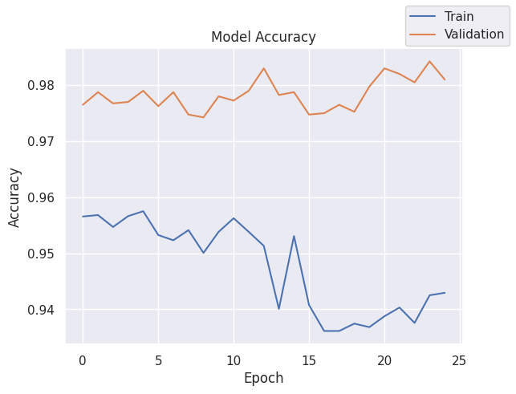

```python
plot(history,'accuracy')
```

```python
model_6_train_perf = model_performance_classification(model, X_train, y_train)
model_6_train_perf
```

```
500/500 ━━━━━━━━━━━━━━━━━━━━ 3s 5ms/step
```

|  | Accuracy | Recall | Precision | F1 Score |
| --- | --- | --- | --- | --- |
| 0 | 0.97675 | 0.97675 | 0.979511 | 0.97773 |

```python
model_6_valid_perf = model_performance_classification(model, X_valid, y_valid)
model_6_valid_perf
```

```
125/125 ━━━━━━━━━━━━━━━━━━━━ 0s 3ms/step
```

|  | Accuracy | Recall | Precision | F1 Score |
| --- | --- | --- | --- | --- |
| 0 | 0.981 | 0.981 | 0.983299 | 0.981768 |

```python
results.loc[6] = [2,str([14,7]),str(["relu","relu"]),25,64,"Adam",str([0.001, "-"]),"he_normal","dropout(0.4, 0.2)",history.history["loss"][-1],history.history["val_loss"][-1],history.history["accuracy"][-1],history.history["val_accuracy"][-1],round(end-start,2)]
```

```python
results
```

|  | # hidden layers | # neurons - hidden layer | activation function - hidden layer | # epochs | batch size | optimizer | learning rate, momentum | weight initializer | regularization | train loss | validation loss | train accuracy | validation accuracy | time (secs) |
| --- | --- | --- | --- | --- | --- | --- | --- | --- | --- | --- | --- | --- | --- | --- |
| 0 | 2 | [14, 7] | ['relu', 'relu'] | 25 | 64 | sgd | [0.001, '-'] | xavier | - | 0.357475 | 0.152401 | 0.973375 | 0.96900 | 36.58 |
| 1 | 2 | [14, 7] | ['relu', 'relu'] | 25 | 64 | sgd with momentum | [0.001, 0.9] | xavier | - | 0.320486 | 0.144340 | 0.975187 | 0.96850 | 32.60 |
| 2 | 2 | [14, 7] | ['relu', 'relu'] | 25 | 64 | Adam | [0.001, '-'] | xavier | - | 0.347200 | 0.138396 | 0.972687 | 0.96850 | 31.83 |
| 3 | 2 | [14, 7] | ['relu', 'relu'] | 25 | 64 | Adam | [0.001, '-'] | xavier | dropout(0.4, 0.2) | 0.334023 | 0.111131 | 0.972313 | 0.98100 | 38.76 |
| 4 | 2 | [14, 7] | ['relu', 'relu'] | 25 | 64 | Adam | [0.001, '-'] | xavier | dropout(0.4, 0.2) | 0.334023 | 0.111131 | 0.972313 | 0.98100 | 38.76 |
| 5 | 2 | [14, 7] | ['relu', 'relu'] | 25 | 64 | Adam | [0.001, '-'] | xavier | dropout(0.4, 0.2) | 0.617260 | 0.192033 | 0.917375 | 0.96075 | 44.72 |
| 6 | 2 | [14, 7] | ['relu', 'relu'] | 25 | 64 | Adam | [0.001, '-'] | he_normal | dropout(0.4, 0.2) | 0.532666 | 0.171215 | 0.942937 | 0.98100 | 33.15 |

- There's a slight improvement in the scores.
- The difference between train and validation scores has also reduced.

### Model 7

- Let's increase the neurons to 128,64.

```python
# clears the current Keras session, resetting all layers and models previously created, freeing up memory and resources.
tf.keras.backend.clear_session()
```

```python
#Initializing the neural network
model = Sequential()
model.add(Dense(128,activation="relu",kernel_initializer="he_normal",input_dim=X_train.shape[1]))
model.add(Dropout(0.4))
model.add(Dense(64,activation="relu",kernel_initializer="he_normal"))
model.add(Dropout(0.2))
model.add(Dense(1,activation="sigmoid",kernel_initializer="he_normal"))
```

```python
model.summary()
```

```
Model: "sequential"
```

```
┏━━━━━━━━━━━━━━━━━━━━━━━━━━━━━━━━━┳━━━━━━━━━━━━━━━━━━━━━━━━┳━━━━━━━━━━━━━━━┓
┃ Layer (type)                    ┃ Output Shape           ┃       Param # ┃
┡━━━━━━━━━━━━━━━━━━━━━━━━━━━━━━━━━╇━━━━━━━━━━━━━━━━━━━━━━━━╇━━━━━━━━━━━━━━━┩
│ dense (Dense)                   │ (None, 128)            │         5,248 │
├─────────────────────────────────┼────────────────────────┼───────────────┤
│ dropout (Dropout)               │ (None, 128)            │             0 │
├─────────────────────────────────┼────────────────────────┼───────────────┤
│ dense_1 (Dense)                 │ (None, 64)             │         8,256 │
├─────────────────────────────────┼────────────────────────┼───────────────┤
│ dropout_1 (Dropout)             │ (None, 64)             │             0 │
├─────────────────────────────────┼────────────────────────┼───────────────┤
│ dense_2 (Dense)                 │ (None, 1)              │            65 │
└─────────────────────────────────┴────────────────────────┴───────────────┘
```

```
 Total params: 13,569 (53.00 KB)
```

```
 Trainable params: 13,569 (53.00 KB)
```

```
 Non-trainable params: 0 (0.00 B)
```

```python
optimizer = tf.keras.optimizers.Adam()    # defining Adam as the optimizer to be used
model.compile(loss='binary_crossentropy', optimizer=optimizer, metrics=['accuracy'])
```

```python
start = time.time()
history = model.fit(X_train, y_train, validation_data=(X_valid,y_valid) , batch_size=batch_size, epochs=epochs,class_weight=cw_dict)
end=time.time()
```

```
250/250 ━━━━━━━━━━━━━━━━━━━━ 3s 11ms/step - accuracy: 0.9807 - loss: 0.2366 - val_accuracy: 0.9890 - val_loss: 0.0996
250/250 ━━━━━━━━━━━━━━━━━━━━ 4s 8ms/step - accuracy: 0.9813 - loss: 0.2317 - val_accuracy: 0.9858 - val_loss: 0.1035
250/250 ━━━━━━━━━━━━━━━━━━━━ 2s 4ms/step - accuracy: 0.9825 - loss: 0.2291 - val_accuracy: 0.9883 - val_loss: 0.1038
250/250 ━━━━━━━━━━━━━━━━━━━━ 1s 4ms/step - accuracy: 0.9843 - loss: 0.2290 - val_accuracy: 0.9887 - val_loss: 0.0973
250/250 ━━━━━━━━━━━━━━━━━━━━ 1s 4ms/step - accuracy: 0.9836 - loss: 0.2162 - val_accuracy: 0.9877 - val_loss: 0.1023
250/250 ━━━━━━━━━━━━━━━━━━━━ 1s 5ms/step - accuracy: 0.9822 - loss: 0.2374 - val_accuracy: 0.9870 - val_loss: 0.1146
250/250 ━━━━━━━━━━━━━━━━━━━━ 2s 6ms/step - accuracy: 0.9823 - loss: 0.2311 - val_accuracy: 0.9890 - val_loss: 0.1041
250/250 ━━━━━━━━━━━━━━━━━━━━ 2s 6ms/step - accuracy: 0.9827 - loss: 0.2178 - val_accuracy: 0.9875 - val_loss: 0.1045
250/250 ━━━━━━━━━━━━━━━━━━━━ 2s 4ms/step - accuracy: 0.9822 - loss: 0.2419 - val_accuracy: 0.9890 - val_loss: 0.0888
250/250 ━━━━━━━━━━━━━━━━━━━━ 1s 4ms/step - accuracy: 0.9822 - loss: 0.2469 - val_accuracy: 0.9893 - val_loss: 0.0936
250/250 ━━━━━━━━━━━━━━━━━━━━ 1s 4ms/step - accuracy: 0.9845 - loss: 0.2073 - val_accuracy: 0.9880 - val_loss: 0.1023
250/250 ━━━━━━━━━━━━━━━━━━━━ 1s 4ms/step - accuracy: 0.9824 - loss: 0.2277 - val_accuracy: 0.9883 - val_loss: 0.0956
250/250 ━━━━━━━━━━━━━━━━━━━━ 1s 4ms/step - accuracy: 0.9838 - loss: 0.2129 - val_accuracy: 0.9890 - val_loss: 0.0909
250/250 ━━━━━━━━━━━━━━━━━━━━ 1s 4ms/step - accuracy: 0.9837 - loss: 0.2307 - val_accuracy: 0.9858 - val_loss: 0.1035
250/250 ━━━━━━━━━━━━━━━━━━━━ 1s 4ms/step - accuracy: 0.9832 - loss: 0.2076 - val_accuracy: 0.9890 - val_loss: 0.0986
250/250 ━━━━━━━━━━━━━━━━━━━━ 1s 4ms/step - accuracy: 0.9847 - loss: 0.2050 - val_accuracy: 0.9868 - val_loss: 0.1071
250/250 ━━━━━━━━━━━━━━━━━━━━ 2s 6ms/step - accuracy: 0.9806 - loss: 0.2454 - val_accuracy: 0.9868 - val_loss: 0.0998
250/250 ━━━━━━━━━━━━━━━━━━━━ 2s 4ms/step - accuracy: 0.9819 - loss: 0.2276 - val_accuracy: 0.9880 - val_loss: 0.0992
250/250 ━━━━━━━━━━━━━━━━━━━━ 1s 4ms/step - accuracy: 0.9828 - loss: 0.2078 - val_accuracy: 0.9885 - val_loss: 0.0908
250/250 ━━━━━━━━━━━━━━━━━━━━ 1s 4ms/step - accuracy: 0.9821 - loss: 0.2335 - val_accuracy: 0.9887 - val_loss: 0.0889
250/250 ━━━━━━━━━━━━━━━━━━━━ 1s 4ms/step - accuracy: 0.9840 - loss: 0.2114 - val_accuracy: 0.9865 - val_loss: 0.1019
250/250 ━━━━━━━━━━━━━━━━━━━━ 1s 4ms/step - accuracy: 0.9813 - loss: 0.2209 - val_accuracy: 0.9887 - val_loss: 0.0960
250/250 ━━━━━━━━━━━━━━━━━━━━ 1s 4ms/step - accuracy: 0.9848 - loss: 0.2152 - val_accuracy: 0.9885 - val_loss: 0.0973
250/250 ━━━━━━━━━━━━━━━━━━━━ 1s 4ms/step - accuracy: 0.9809 - loss: 0.2310 - val_accuracy: 0.9883 - val_loss: 0.0874
250/250 ━━━━━━━━━━━━━━━━━━━━ 1s 4ms/step - accuracy: 0.9804 - loss: 0.2386 - val_accuracy: 0.9875 - val_loss: 0.1018
```

```python
print("Time taken in seconds ",end-start)
```

```
Time taken in seconds  38.434704065322876
```

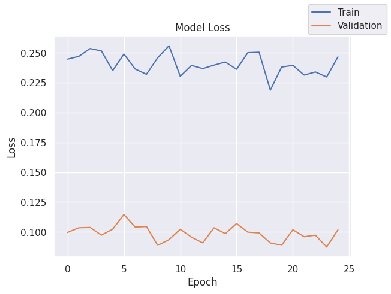

```python
plot(history,'loss')
```

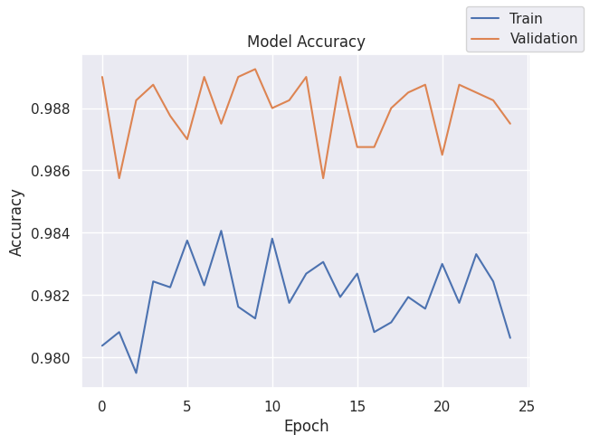

```python
plot(history,'accuracy')
```

```python
model_7_train_perf = model_performance_classification(model, X_train, y_train)
model_7_train_perf
```

```
500/500 ━━━━━━━━━━━━━━━━━━━━ 1s 1ms/step
```

|  | Accuracy | Recall | Precision | F1 Score |
| --- | --- | --- | --- | --- |
| 0 | 0.991563 | 0.991563 | 0.9919 | 0.991682 |

```python
model_7_valid_perf = model_performance_classification(model, X_valid, y_valid)
model_7_valid_perf
```

```
125/125 ━━━━━━━━━━━━━━━━━━━━ 0s 2ms/step
```

|  | Accuracy | Recall | Precision | F1 Score |
| --- | --- | --- | --- | --- |
| 0 | 0.9875 | 0.9875 | 0.987958 | 0.987679 |

```python
results.loc[7] = [2,str([128,64]),str(["relu","relu"]),25,64,"Adam",str([0.001, "-"]),"he_normal","dropout(0.4, 0.2)",history.history["loss"][-1],history.history["val_loss"][-1],history.history["accuracy"][-1],history.history["val_accuracy"][-1],round(end-start,2)]
```

```python
results
```

|  | # hidden layers | # neurons - hidden layer | activation function - hidden layer | # epochs | batch size | optimizer | learning rate, momentum | weight initializer | regularization | train loss | validation loss | train accuracy | validation accuracy | time (secs) |
| --- | --- | --- | --- | --- | --- | --- | --- | --- | --- | --- | --- | --- | --- | --- |
| 0 | 2 | [14, 7] | ['relu', 'relu'] | 25 | 64 | sgd | [0.001, '-'] | xavier | - | 0.357475 | 0.152401 | 0.973375 | 0.96900 | 36.58 |
| 1 | 2 | [14, 7] | ['relu', 'relu'] | 25 | 64 | sgd with momentum | [0.001, 0.9] | xavier | - | 0.320486 | 0.144340 | 0.975187 | 0.96850 | 32.60 |
| 2 | 2 | [14, 7] | ['relu', 'relu'] | 25 | 64 | Adam | [0.001, '-'] | xavier | - | 0.347200 | 0.138396 | 0.972687 | 0.96850 | 31.83 |
| 3 | 2 | [14, 7] | ['relu', 'relu'] | 25 | 64 | Adam | [0.001, '-'] | xavier | dropout(0.4, 0.2) | 0.334023 | 0.111131 | 0.972313 | 0.98100 | 38.76 |
| 4 | 2 | [14, 7] | ['relu', 'relu'] | 25 | 64 | Adam | [0.001, '-'] | xavier | - | 0.532666 | 0.171215 | 0.942937 | 0.98100 | 33.15 |
| 5 | 2 | [14, 7] | ['relu', 'relu'] | 25 | 64 | Adam | [0.001, '-'] | xavier | dropout(0.4, 0.2) | 0.617260 | 0.192033 | 0.917375 | 0.96075 | 44.72 |
| 6 | 2 | [128, 64] | ['relu', 'relu'] | 25 | 64 | Adam | [0.001, '-'] | he_normal | dropout(0.4, 0.2) | 0.319370 | 0.118356 | 0.980062 | 0.98850 | 36.59 |
| 7 | 2 | [128, 64] | ['relu', 'relu'] | 25 | 64 | Adam | [0.001, '-'] | he_normal | dropout(0.4, 0.2) | 0.246631 | 0.101820 | 0.980625 | 0.98750 | 38.43 |

## Model Performance Comparison and Final Model Selection

```python
# training performance comparison

models_train_comp_df = pd.concat(
    [
        model_0_train_perf.T,
        model_1_train_perf.T,
        model_2_train_perf.T,
        model_3_train_perf.T,
        model_4_train_perf.T,
        model_5_train_perf.T,
        model_6_train_perf.T,
        model_7_train_perf.T
    ],
    axis=1,
)
models_train_comp_df.columns = [
    "Neural Network (SGD, No Regularization)",
    "Neural Network (SGD with Momentum, No Regularization)",
    "Neural Network (Adam , No Regularization)",
    "Neural Network (Adam, dropout [0.4,0.2])",
    "Neural Network (Adam, Batch Normalization)",
    "Neural Network (dropout [0.4,0.2], Batch Normalization)",
    "Neural Network (Adam,dropout [0.4,0.2] ,He initialization)",
    "Neural Network (Adam,dropout [0.4,0.2] ,He initialization,Neurons [128,64])"
]
```

```python
#Validation performance comparison

models_valid_comp_df = pd.concat(
    [
        model_0_valid_perf.T,
        model_1_valid_perf.T,
        model_2_valid_perf.T,
        model_3_valid_perf.T,
        model_4_valid_perf.T,
        model_5_valid_perf.T,
        model_6_valid_perf.T,
        model_7_train_perf.T
    ],
    axis=1,
)
models_valid_comp_df.columns = [
    "Neural Network (SGD, No Regularization)",
    "Neural Network (SGD with Momentum, No Regularization)",
    "Neural Network (Adam , No Regularization)",
    "Neural Network (Adam, dropout [0.4,0.2])",
    "Neural Network (Adam, Batch Normalization)",
    "Neural Network (dropout [0.4,0.2], Batch Normalization)",
    "Neural Network (Adam,dropout [0.4,0.2] ,He initialization)",
    "Neural Network (Adam,dropout [0.4,0.2] ,He initialization,Neurons [128,64])"
]
```

```python
models_train_comp_df
```

|  | Neural Network (SGD, No Regularization) | Neural Network (SGD with Momentum, No Regularization) | Neural Network (Adam , No Regularization) | Neural Network (Adam, dropout [0.4,0.2]) | Neural Network (Adam, Batch Normalization) | Neural Network (dropout [0.4,0.2], Batch Normalization) | Neural Network (Adam,dropout [0.4,0.2] ,He initialization) | Neural Network (Adam,dropout [0.4,0.2] ,He initialization,Neurons [128,64]) |
| --- | --- | --- | --- | --- | --- | --- | --- | --- |
| Accuracy | 0.969187 | 0.973688 | 0.968562 | 0.954187 | 0.981938 | 0.952875 | 0.976750 | 0.991563 |
| Recall | 0.969187 | 0.973688 | 0.968562 | 0.954187 | 0.981938 | 0.952875 | 0.976750 | 0.991563 |
| Precision | 0.976358 | 0.978922 | 0.975961 | 0.968798 | 0.983461 | 0.968401 | 0.979511 | 0.991900 |
| F1 Score | 0.971504 | 0.975371 | 0.970960 | 0.959064 | 0.982486 | 0.958051 | 0.977730 | 0.991682 |

```python
models_valid_comp_df
```

|  | Neural Network (SGD, No Regularization) | Neural Network (SGD with Momentum, No Regularization) | Neural Network (Adam , No Regularization) | Neural Network (Adam, dropout [0.4,0.2]) | Neural Network (Adam, Batch Normalization) | Neural Network (dropout [0.4,0.2], Batch Normalization) | Neural Network (Adam,dropout [0.4,0.2] ,He initialization) | Neural Network (Adam,dropout [0.4,0.2] ,He initialization,Neurons [128,64]) |
| --- | --- | --- | --- | --- | --- | --- | --- | --- |
| Accuracy | 0.969000 | 0.968500 | 0.968500 | 0.958000 | 0.981000 | 0.960750 | 0.981000 | 0.991563 |
| Recall | 0.969000 | 0.968500 | 0.968500 | 0.958000 | 0.981000 | 0.960750 | 0.981000 | 0.991563 |
| Precision | 0.976219 | 0.975783 | 0.976179 | 0.971125 | 0.982778 | 0.972860 | 0.983299 | 0.991900 |
| F1 Score | 0.971337 | 0.970874 | 0.970965 | 0.962286 | 0.981633 | 0.964633 | 0.981768 | 0.991682 |

```python
models_train_comp_df.loc["F1 Score"] - models_valid_comp_df.loc["F1 Score"]
```

|  | F1 Score |
| --- | --- |
| Neural Network (SGD, No Regularization) | 0.000168 |
| Neural Network (SGD with Momentum, No Regularization) | 0.004497 |
| Neural Network (Adam , No Regularization) | -0.000004 |
| Neural Network (Adam, dropout [0.4,0.2]) | -0.003222 |
| Neural Network (Adam, Batch Normalization) | 0.000853 |
| Neural Network (dropout [0.4,0.2], Batch Normalization) | -0.006582 |
| Neural Network (Adam,dropout [0.4,0.2] ,He initialization) | -0.004038 |
| Neural Network (Adam,dropout [0.4,0.2] ,He initialization,Neurons [128,64]) | 0.000000 |

**dtype:** float64

Here's the reasoning:

1. **Highest Validation Recall**: Model 7 achieved the highest validation Recall (0.9875) among all models. This is the most critical metric as it directly relates to minimizing the costly False Negatives (undetected failures).
2. **Superior Overall Validation Performance**: In addition to the highest Recall, Model 7 also demonstrated the highest validation Accuracy (0.9875), Precision (0.987958), and F1 Score (0.987679). This indicates a strong overall ability to correctly classify both failure and no-failure instances and a good balance between Precision and Recall.
3. **Improved Architecture and Initialization**: Model 7 incorporated increased neurons (128 and 64), used the Adam optimizer, He Normal weight initialization, and Dropout regularization. This combination appears to have been effective in capturing the underlying patterns in the data and improving predictive performance compared to simpler architectures or different regularization/initialization strategies.
4. **Consistent Performance**: The loss and accuracy plots for Model 7 also showed a good learning trajectory with a relatively small gap between training and validation curves, suggesting good generalization.

### Final Model

```python
# clears the current Keras session, resetting all layers and models previously created, freeing up memory and resources.
tf.keras.backend.clear_session()
```

```python
#Initializing the neural network
model = Sequential()
model.add(Dense(128,activation="relu",kernel_initializer="he_normal",input_dim=X_train.shape[1]))
model.add(Dropout(0.4))
model.add(Dense(64,activation="relu",kernel_initializer="he_normal"))
model.add(Dropout(0.2))
model.add(Dense(1,activation="sigmoid",kernel_initializer="he_normal"))
```

```python
model.summary()
```

```
Model: "sequential"
```

```
┏━━━━━━━━━━━━━━━━━━━━━━━━━━━━━━━━━┳━━━━━━━━━━━━━━━━━━━━━━━━┳━━━━━━━━━━━━━━━┓
┃ Layer (type)                    ┃ Output Shape           ┃       Param # ┃
┡━━━━━━━━━━━━━━━━━━━━━━━━━━━━━━━━━╇━━━━━━━━━━━━━━━━━━━━━━━━╇━━━━━━━━━━━━━━━┩
│ dense (Dense)                   │ (None, 128)            │         5,248 │
├─────────────────────────────────┼────────────────────────┼───────────────┤
│ dropout (Dropout)               │ (None, 128)            │             0 │
├─────────────────────────────────┼────────────────────────┼───────────────┤
│ dense_1 (Dense)                 │ (None, 64)             │         8,256 │
├─────────────────────────────────┼────────────────────────┼───────────────┤
│ dropout_1 (Dropout)             │ (None, 64)             │             0 │
├─────────────────────────────────┼────────────────────────┼───────────────┤
│ dense_2 (Dense)                 │ (None, 1)              │            65 │
└─────────────────────────────────┴────────────────────────┴───────────────┘
```

```
 Total params: 13,569 (53.00 KB)
```

```
 Trainable params: 13,569 (53.00 KB)
```

```
 Non-trainable params: 0 (0.00 B)
```

```python
optimizer = tf.keras.optimizers.Adam()    # defining Adam as the optimizer to be used
model.compile(loss='binary_crossentropy', optimizer=optimizer, metrics=['accuracy'])
```

```python
start = time.time()
history = model.fit(X_train, y_train, validation_data=(X_valid,y_valid) , batch_size=batch_size, epochs=epochs,class_weight=cw_dict)
end=time.time()
```

```
250/250 ━━━━━━━━━━━━━━━━━━━━ 4s 10ms/step - accuracy: 0.7640 - loss: 1.3403 - val_accuracy: 0.7797 - val_loss: 0.4482
250/250 ━━━━━━━━━━━━━━━━━━━━ 3s 10ms/step - accuracy: 0.8425 - loss: 0.7046 - val_accuracy: 0.8610 - val_loss: 0.3322
250/250 ━━━━━━━━━━━━━━━━━━━━ 1s 5ms/step - accuracy: 0.8843 - loss: 0.6136 - val_accuracy: 0.9187 - val_loss: 0.2451
250/250 ━━━━━━━━━━━━━━━━━━━━ 2s 5ms/step - accuracy: 0.9062 - loss: 0.5728 - val_accuracy: 0.9237 - val_loss: 0.2428
250/250 ━━━━━━━━━━━━━━━━━━━━ 1s 5ms/step - accuracy: 0.9174 - loss: 0.5341 - val_accuracy: 0.9498 - val_loss: 0.2065
250/250 ━━━━━━━━━━━━━━━━━━━━ 1s 4ms/step - accuracy: 0.9345 - loss: 0.4767 - val_accuracy: 0.9588 - val_loss: 0.1904
250/250 ━━━━━━━━━━━━━━━━━━━━ 1s 4ms/step - accuracy: 0.9410 - loss: 0.4948 - val_accuracy: 0.9590 - val_loss: 0.2016
250/250 ━━━━━━━━━━━━━━━━━━━━ 1s 4ms/step - accuracy: 0.9461 - loss: 0.4529 - val_accuracy: 0.9728 - val_loss: 0.1623
250/250 ━━━━━━━━━━━━━━━━━━━━ 2s 6ms/step - accuracy: 0.9547 - loss: 0.4426 - val_accuracy: 0.9762 - val_loss: 0.1592
250/250 ━━━━━━━━━━━━━━━━━━━━ 2s 6ms/step - accuracy: 0.9569 - loss: 0.4391 - val_accuracy: 0.9793 - val_loss: 0.1568
250/250 ━━━━━━━━━━━━━━━━━━━━ 1s 5ms/step - accuracy: 0.9626 - loss: 0.3960 - val_accuracy: 0.9770 - val_loss: 0.1598
250/250 ━━━━━━━━━━━━━━━━━━━━ 1s 4ms/step - accuracy: 0.9651 - loss: 0.3987 - val_accuracy: 0.9812 - val_loss: 0.1471
250/250 ━━━━━━━━━━━━━━━━━━━━ 1s 4ms/step - accuracy: 0.9661 - loss: 0.4021 - val_accuracy: 0.9840 - val_loss: 0.1389
250/250 ━━━━━━━━━━━━━━━━━━━━ 1s 5ms/step - accuracy: 0.9679 - loss: 0.3844 - val_accuracy: 0.9825 - val_loss: 0.1419
250/250 ━━━━━━━━━━━━━━━━━━━━ 1s 5ms/step - accuracy: 0.9726 - loss: 0.3700 - val_accuracy: 0.9805 - val_loss: 0.1579
250/250 ━━━━━━━━━━━━━━━━━━━━ 1s 4ms/step - accuracy: 0.9715 - loss: 0.3555 - val_accuracy: 0.9862 - val_loss: 0.1383
250/250 ━━━━━━━━━━━━━━━━━━━━ 1s 4ms/step - accuracy: 0.9696 - loss: 0.3673 - val_accuracy: 0.9858 - val_loss: 0.1268
250/250 ━━━━━━━━━━━━━━━━━━━━ 1s 4ms/step - accuracy: 0.9729 - loss: 0.3510 - val_accuracy: 0.9847 - val_loss: 0.1468
250/250 ━━━━━━━━━━━━━━━━━━━━ 1s 4ms/step - accuracy: 0.9763 - loss: 0.3660 - val_accuracy: 0.9885 - val_loss: 0.1353
250/250 ━━━━━━━━━━━━━━━━━━━━ 2s 6ms/step - accuracy: 0.9748 - loss: 0.3390 - val_accuracy: 0.9895 - val_loss: 0.1178
250/250 ━━━━━━━━━━━━━━━━━━━━ 1s 6ms/step - accuracy: 0.9796 - loss: 0.3360 - val_accuracy: 0.9855 - val_loss: 0.1349
250/250 ━━━━━━━━━━━━━━━━━━━━ 1s 5ms/step - accuracy: 0.9745 - loss: 0.3545 - val_accuracy: 0.9880 - val_loss: 0.1225
250/250 ━━━━━━━━━━━━━━━━━━━━ 2s 4ms/step - accuracy: 0.9780 - loss: 0.3283 - val_accuracy: 0.9895 - val_loss: 0.1305
250/250 ━━━━━━━━━━━━━━━━━━━━ 1s 4ms/step - accuracy: 0.9788 - loss: 0.3298 - val_accuracy: 0.9858 - val_loss: 0.1418
250/250 ━━━━━━━━━━━━━━━━━━━━ 1s 4ms/step - accuracy: 0.9776 - loss: 0.3183 - val_accuracy: 0.9883 - val_loss: 0.1294
```

```python
y_train_pred = model.predict(X_train)
y_valid_pred = model.predict(X_valid)
y_test_pred = model.predict(X_test)
```

```
500/500 ━━━━━━━━━━━━━━━━━━━━ 1s 1ms/step
125/125 ━━━━━━━━━━━━━━━━━━━━ 0s 2ms/step
157/157 ━━━━━━━━━━━━━━━━━━━━ 0s 2ms/step
```

```python
print("Classification Report - Train data",end="\n\n")
cr = classification_report(y_train,y_train_pred>0.5)
print(cr)
```

```
Classification Report - Train data

              precision    recall  f1-score   support

           0       1.00      0.99      0.99     15112
           1       0.87      0.92      0.89       888

    accuracy                           0.99     16000
   macro avg       0.93      0.95      0.94     16000
weighted avg       0.99      0.99      0.99     16000
```

```python
print("Classification Report - Validation data",end="\n\n")
cr = classification_report(y_valid,y_valid_pred>0.5)
print(cr)
```

```
Classification Report - Validation data

              precision    recall  f1-score   support

           0       1.00      0.99      0.99      3778
           1       0.88      0.92      0.90       222

    accuracy                           0.99      4000
   macro avg       0.94      0.96      0.95      4000
weighted avg       0.99      0.99      0.99      4000
```

```python
print("Classification Report - Test data",end="\n\n")
cr = classification_report(Y_test,y_test_pred>0.5)
print(cr)
```

```
Classification Report - Test data

              precision    recall  f1-score   support

           0       0.99      0.99      0.99      4718
           1       0.88      0.88      0.88       282

    accuracy                           0.99      5000
   macro avg       0.93      0.94      0.94      5000
weighted avg       0.99      0.99      0.99      5000
```

```python
model_7_valid_perf = model_performance_classification(model, X_test, Y_test)
model_7_valid_perf
```

```
157/157 ━━━━━━━━━━━━━━━━━━━━ 0s 2ms/step
```

|  | Accuracy | Recall | Precision | F1 Score |
| --- | --- | --- | --- | --- |
| 0 | 0.9862 | 0.9862 | 0.986223 | 0.986211 |

**Observations on Model 7 Performance on Test Data:**

- **Overall High Performance**: The model maintains high performance on the test data, with an overall accuracy of 0.9862 and a weighted average F1 score of 0.99.
- **Strong Majority Class Prediction**: Similar to the training and validation sets, the model performs exceptionally well on the majority class (No Failure), with high precision, recall, and F1-score (all 0.99).
- **Good Minority Class Prediction**: For the minority class (Failure), the model achieves a precision of 0.88 and a recall of 0.88. This means that when the model predicts a failure on the test set, it is correct 88% of the time, and it correctly identifies 88% of the actual failures.
- **Reasonable Balance**: The F1-score for the minority class is 0.88, indicating a good balance between precision and recall for predicting failures on unseen data.
- **Consistency**: The performance on the test data is consistent with the performance observed on the validation data, suggesting that the model generalizes well to unseen data. Conclusion:

The final model (Model 7) demonstrates strong performance on the test dataset, effectively handling the class imbalance and achieving a good balance between identifying actual failures (Recall) and minimizing false alarms (Precision). The high Recall for the minority class is particularly important for this problem's objective of minimizing costly generator replacements.

## Conclusion and Recommendations

**Actionable Insights & Recommendations:**

1. **High Recall for Failure Prediction:** The final model demonstrates a good ability to identify actual generator failures (Recall of 0.88 for the failure class on unseen test data). This is crucial for ReneWind as it helps minimize costly generator replacements by allowing for predictive maintenance.
2. **Manageable False Positives:** While prioritizing Recall, the model also maintains a reasonable Precision of 0.88 for the failure class. This means that when the model predicts a failure, it is correct most of the time, which helps keep inspection costs due to false alarms in check.
3. **Utilize Model for Predictive Maintenance:** Implement the developed neural network model within ReneWind's operational framework. The model's predictions can be used to schedule inspections and maintenance for generators identified as likely to fail.
4. **Set an Appropriate Probability Threshold:** The current evaluation uses a default threshold of 0.5 for classifying predictions. Depending on the exact costs of inspection versus replacement, the probability threshold can be adjusted to further optimize the trade-off between False Positives and False Negatives. A lower threshold would increase Recall (identifying more failures) but potentially decrease Precision (more false alarms and inspection costs). A cost-benefit analysis based on the actual costs provided by ReneWind would be beneficial to determine the optimal threshold.
5. **Continuous Monitoring and Retraining:** Sensor data can change over time due to various factors (e.g., environmental changes, aging of turbines). It is recommended to continuously monitor the model's performance on new data and retrain the model periodically with the latest data to ensure its predictions remain accurate and relevant.
6. **Investigate False Negatives:** Although the Recall is high, there are still some False Negatives (actual failures not predicted by the model). Investigating these instances could provide valuable insights into failure patterns not captured by the current features or model, potentially leading to improvements in data collection or model architecture.
7. **Explore Feature Importance:** While the features are ciphered, exploring techniques to understand which features contribute most to the model's predictions could be beneficial. This might involve using model interpretation techniques (if applicable to this type of model and data) or working with ReneWind to understand the potential real-world meaning behind the most influential ciphered features. This could lead to insights for improving sensor data collection or turbine design.
8. **Consider Advanced Techniques for Imbalanced Data:** While class weights were used, further exploration of other techniques for handling class imbalance (e.g., oversampling the minority class, undersampling the majority class, using specialized algorithms) could potentially yield further improvements.

By implementing this model and following these recommendations, ReneWind can significantly enhance its predictive maintenance capabilities, leading to reduced operational and maintenance costs associated with wind turbine generator failures.